# Thyroid Cancer Recurrence

Axelle MERIC

Academic Year 2025-2026

# Preliminary

We begin by loading the necessary packages for this analysis. We precise that the code of this project has been commented when it was thought needed, for example when introducing new functions.

```r
library(tidyverse)
library(rsample)
library(scales)
library(dplyr)
library(tidyr)
library(glue)
library(corrplot)
library(ggfortify)
library(carData)
library(car)
library(MASS)
library(ggplot2)
library(DataExplorer)
library(skimr)
library(plotly)
library(gridExtra)
library(grid)
library(rlang)
library(caret)
library(rcompanion) #cramerV
library(reshape2)
library(class)
library(ROCR)
library(randomForest)
```

# 1. Introduction

The aim of this project is to study Thyroid Cancer Recurrence given medical information of the patient. This project of data visualisation is based on a previous project done in statistical learning course of Master 1. It was done in Python and we will use some of the developed model to focus here on the visualisation part.

## 1.1. Dataset Presentation

In this project we use the following dataset.

```r
data <- read_csv("Thyroid_Diff.csv")
head(data, 10)
```

| Age | Gender | Smoking | Hx Smoking | Hx Radiothreapy | Thyroid Function | Physical Examination | Adenopathy | Pathology | Focality | Risk | T | N | M | Stage | Response | Recurred |
| --- | --- | --- | --- | --- | --- | --- | --- | --- | --- | --- | --- | --- | --- | --- | --- | --- |
| 27 | F | No | No | No | Euthyroid | Single nodular goiter-left | No | Micropapillary | Uni-Focal | Low | T1a | N0 | M0 | I | Indeterminate | No |
| 34 | F | No | Yes | No | Euthyroid | Multinodular goiter | No | Micropapillary | Uni-Focal | Low | T1a | N0 | M0 | I | Excellent | No |
| 30 | F | No | No | No | Euthyroid | Single nodular goiter-right | No | Micropapillary | Uni-Focal | Low | T1a | N0 | M0 | I | Excellent | No |
| 62 | F | No | No | No | Euthyroid | Single nodular goiter-right | No | Micropapillary | Uni-Focal | Low | T1a | N0 | M0 | I | Excellent | No |
| 62 | F | No | No | No | Euthyroid | Multinodular goiter | No | Micropapillary | Multi-Focal | Low | T1a | N0 | M0 | I | Excellent | No |
| 52 | M | Yes | No | No | Euthyroid | Multinodular goiter | No | Micropapillary | Multi-Focal | Low | T1a | N0 | M0 | I | Indeterminate | No |
| 41 | F | No | Yes | No | Clinical Hyperthyroidism | Single nodular goiter-right | No | Micropapillary | Uni-Focal | Low | T1a | N0 | M0 | I | Excellent | No |
| 46 | F | No | No | No | Euthyroid | Single nodular goiter-right | No | Micropapillary | Uni-Focal | Low | T1a | N0 | M0 | I | Excellent | No |
| 51 | F | No | No | No | Euthyroid | Single nodular goiter-right | No | Micropapillary | Uni-Focal | Low | T1a | N0 | M0 | I | Excellent | No |
| 40 | F | No | No | No | Euthyroid | Single nodular goiter-right | No | Micropapillary | Uni-Focal | Low | T1a | N0 | M0 | I | Excellent | No |

```r
summary(data)
```

```
##       Age           Gender            Smoking           Hx Smoking
##  Min.   :15.00   Length:383         Length:383         Length:383
##  1st Qu.:29.00   Class :character   Class :character   Class :character
##  Median :37.00   Mode  :character   Mode  :character   Mode  :character
##  Mean   :40.87
##  3rd Qu.:51.00
##  Max.   :82.00
##  Hx Radiothreapy    Thyroid Function   Physical Examination  Adenopathy
##  Length:383         Length:383         Length:383           Length:383
##  Class :character   Class :character   Class :character     Class :character
##  Mode  :character   Mode  :character   Mode  :character     Mode  :character
##
##
##
##   Pathology           Focality             Risk                T
##  Length:383         Length:383         Length:383         Length:383
##  Class :character   Class :character   Class :character   Class :character
##  Mode  :character   Mode  :character   Mode  :character   Mode  :character
##
##
##
##       N                  M                Stage             Response
##  Length:383         Length:383         Length:383         Length:383
##  Class :character   Class :character   Class :character   Class :character
##  Mode  :character   Mode  :character   Mode  :character   Mode  :character
##
##
##
##    Recurred
##  Length:383
##  Class :character
##  Mode  :character
##
##
##
```

It consists of 383 patients who had previously had thyroid cancer.

```r
cat("Rows:", nrow(data), "\n")
```

```
## Rows: 383
```

```r
cat("Columns:", ncol(data), "\n")
```

```
## Columns: 17
```

There is exactly one continuous feature, which is `Age`. The 15 other features are categorical ones. The target variable is `Recurred`, which indicates whether or not the cancer recurred for each patient. The problem can be formulated as a supervised binary classification task, where the goal is to predict the recurrence of thyroid cancer using a set of clinical and pathological features.

```r
skimr::skim(data)  |> rmarkdown::paged_table()
```

|  | skim_type | skim_variable | n_missing | complete_rate | character.min | character.max | character.empty | character.n_unique | character.whitespace | numeric.mean | numeric.sd | numeric.p0 | numeric.p25 | numeric.p50 | numeric.p75 | numeric.p100 | numeric.hist |
| --- | --- | --- | --- | --- | --- | --- | --- | --- | --- | --- | --- | --- | --- | --- | --- | --- | --- |
| 1 | character | Gender | 0 | 1 | 1 | 1 | 0 | 2 | 0 | NA | NA | NA | NA | NA | NA | NA | NA |
| 2 | character | Smoking | 0 | 1 | 2 | 3 | 0 | 2 | 0 | NA | NA | NA | NA | NA | NA | NA | NA |
| 3 | character | Hx Smoking | 0 | 1 | 2 | 3 | 0 | 2 | 0 | NA | NA | NA | NA | NA | NA | NA | NA |
| 4 | character | Hx Radiothreapy | 0 | 1 | 2 | 3 | 0 | 2 | 0 | NA | NA | NA | NA | NA | NA | NA | NA |
| 5 | character | Thyroid Function | 0 | 1 | 9 | 27 | 0 | 5 | 0 | NA | NA | NA | NA | NA | NA | NA | NA |
| 6 | character | Physical Examination | 0 | 1 | 6 | 27 | 0 | 5 | 0 | NA | NA | NA | NA | NA | NA | NA | NA |
| 7 | character | Adenopathy | 0 | 1 | 2 | 9 | 0 | 6 | 0 | NA | NA | NA | NA | NA | NA | NA | NA |
| 8 | character | Pathology | 0 | 1 | 9 | 14 | 0 | 4 | 0 | NA | NA | NA | NA | NA | NA | NA | NA |
| 9 | character | Focality | 0 | 1 | 9 | 11 | 0 | 2 | 0 | NA | NA | NA | NA | NA | NA | NA | NA |
| 10 | character | Risk | 0 | 1 | 3 | 12 | 0 | 3 | 0 | NA | NA | NA | NA | NA | NA | NA | NA |

[output cut: 7 more lines]

As observe in the summary and the first lines of the dataset, we begin by changing the type of the categorical features from character to factor. And we also correct the name of one of the feature.

```r
data <- data |>
  rename_with(~ sub("Radiothreapy", "Radiotherapy", .x)) |>
  mutate(Gender = as.factor(Gender),
         Smoking = as.factor(Smoking),
         `Hx Smoking` = as.factor(`Hx Smoking`),
         `Hx Radiotherapy` = as.factor(`Hx Radiotherapy`),
         `Thyroid Function` = as.factor(`Thyroid Function`),
         `Physical Examination` = as.factor(`Physical Examination`),
         Adenopathy = as.factor(Adenopathy),
         Pathology = as.factor(Pathology),
         Focality = as.factor(Focality),
         Risk = as.factor(Risk),
         T = as.factor(T),
         N = as.factor(N),
         M = as.factor(M),
         Stage = as.factor(Stage),
         Response = as.factor(Response),
         Recurred = as.factor(Recurred)
  )

head(data, 10) |> rmarkdown::paged_table()
```

| Age | Gender | Smoking | Hx Smoking | Hx Radiotherapy | Thyroid Function | Physical Examination | Adenopathy | Pathology | Focality | Risk | T | N | M | Stage | Response | Recurred |
| --- | --- | --- | --- | --- | --- | --- | --- | --- | --- | --- | --- | --- | --- | --- | --- | --- |
| 27 | F | No | No | No | Euthyroid | Single nodular goiter-left | No | Micropapillary | Uni-Focal | Low | T1a | N0 | M0 | I | Indeterminate | No |
| 34 | F | No | Yes | No | Euthyroid | Multinodular goiter | No | Micropapillary | Uni-Focal | Low | T1a | N0 | M0 | I | Excellent | No |
| 30 | F | No | No | No | Euthyroid | Single nodular goiter-right | No | Micropapillary | Uni-Focal | Low | T1a | N0 | M0 | I | Excellent | No |
| 62 | F | No | No | No | Euthyroid | Single nodular goiter-right | No | Micropapillary | Uni-Focal | Low | T1a | N0 | M0 | I | Excellent | No |
| 62 | F | No | No | No | Euthyroid | Multinodular goiter | No | Micropapillary | Multi-Focal | Low | T1a | N0 | M0 | I | Excellent | No |
| 52 | M | Yes | No | No | Euthyroid | Multinodular goiter | No | Micropapillary | Multi-Focal | Low | T1a | N0 | M0 | I | Indeterminate | No |
| 41 | F | No | Yes | No | Clinical Hyperthyroidism | Single nodular goiter-right | No | Micropapillary | Uni-Focal | Low | T1a | N0 | M0 | I | Excellent | No |
| 46 | F | No | No | No | Euthyroid | Single nodular goiter-right | No | Micropapillary | Uni-Focal | Low | T1a | N0 | M0 | I | Excellent | No |
| 51 | F | No | No | No | Euthyroid | Single nodular goiter-right | No | Micropapillary | Uni-Focal | Low | T1a | N0 | M0 | I | Excellent | No |
| 40 | F | No | No | No | Euthyroid | Single nodular goiter-right | No | Micropapillary | Uni-Focal | Low | T1a | N0 | M0 | I | Excellent | No |

## 1.2. Features analysis

Before building any model, the first step is to explore the features and understand the structure of the dataset. In this section, we conduct a variable analysis to get an overview of the main features and their behavior.

### 1.2.1. Target variable

We begin our study with the target variable `Recurred` which has two modalities: `Yes` and `No`. Knowing that the patient previously had cancer, it takes the value `Yes` if the cancer recurred after initial treatment and `No` otherwise.

```r
target <- data$Recurred

unique(target) #return the factors of a categorical feature
```

```
## [1] No  Yes
## Levels: No Yes
```

One can see first with a `summary()` and also in the distribution that the distribuion is unbalanced.

```r
summary(target)
```

```
##  No Yes
## 275 108
```

```r
tar_dist_plot <- ggplot(data, aes(x = Recurred, fill = Recurred)) + #structure of the plot
  geom_bar() + #draw the two bars
  geom_text(stat='count', aes(label=..count..)) + #add the number on each bar
  theme_minimal() +
  scale_fill_manual(values = c("No" = "#983399", "Yes" = "#E4CBF9")) + #associate my colour
  labs(title = "Distribution of the taret variable: Recurrence",
       x = "Recurrence Status",
       y = "Number of Patients",
       fill = "Recurred") #print the title

ggplotly(tar_dist_plot) #we choose an interactive plot
```

[interactive chart not shown]

### 1.2.2. Analysis of ofother relevant features

Now, let us look at the only numerical feature: `Age`.It ranges from 15 to 82. The mean (40.87) is slightly higher that the median (37.00).

```r
summary(data$Age)
```

```
##    Min. 1st Qu.  Median    Mean 3rd Qu.    Max.
##   15.00   29.00   37.00   40.87   51.00   82.00
```

It is consistent with the peak of values that we observe around the age 31 in the two following figures. The first one shows the general distribution of the feature and the second one breaks it down by recurrence status.

```r
age_dist <- ggplot(data, aes(x = Age)) +
  geom_histogram(aes(y = ..density..), binwidth = 1, fill = "#E4CBF9", color = "white", lwd = 0.1,  alpha = 0.8) + #draw the histogram
  geom_line(stat = "density", color = "#983399", size = 1) + #draw the mean line = the density
  theme_minimal() +
  labs(title = "Age distribution", x = "Age", y = "Densité")

ggplotly(age_dist)
```

[interactive chart not shown]

```r
age_dist_mod <- ggplot(data, aes(x = Age, fill = Recurred)) +
  geom_histogram(bins = 30, position = "stack", color = "white", alpha = 0.8) +
  scale_fill_manual(values = c("No" = "#983399", "Yes" = "#E4CBF9")) +
  theme_minimal() +
  labs(title = 'Age Distribution by Recurrence Status',
       x = 'Age', y = 'Count')

ggplotly(age_dist_mod)
```

[interactive chart not shown]

Furthermore, as we draw the boxplots for the two modalities, we observe a larger interquantile range for the recurrent case. It can be partly explained by the fact that there are less values so it is less precise and it also indicates a greater variability in the age profile of patients who relapse. The black diamond represents the mean. The mean of the recurrent modality is higher than the mean of the other modality. This trend is confirmed by the median represented by the horizontal line in the boxplot, which is clearly elevated for the `Yes` group compared to the `No` group, suggesting that an advanced age is a significant risk factor for cancer recurrence. Finally, we can observe distinct outliers in the `No` group, representing older patients who, despite their age, did not experience recurrence.

```r
age_boxplot <- ggplot(data, aes(y=Age , x= Recurred ,colour=Recurred ,fill= Recurred))+
  geom_boxplot(alpha=0.8, outlier.alpha=0)+
  geom_jitter(width=0.25,size=1)+ #plot the points
  scale_fill_manual(values = c("No" = "#983399", "Yes"    = "#E4CBF9") ) + #colour for the border of the boxplot
  scale_colour_manual(values = c( "No" = "#983399", "Yes" = "#E4CBF9" ))+ #colour for the inside of the boxplot
  stat_summary(fun=mean, colour="black", geom="point",shape=18, size=3)+ #black diamonds for the mean
  theme_minimal() +
  labs(title = "Age Distribution vs Recurrence Target",
       x = "Recurrence Status", y = "Age (Years)",
       fill = "Recurred", colour = "Recurred")

ggplotly(age_boxplot)
```

[interactive chart not shown]

For all other features, the categorical ones, we print the following plots: a distribution among the recurrence status and a table with the precise number and percentage in each couple of modalities. To do so, we define a list with all the different categorical features and we implement a loop on them. Here is the code for the loop. After it will be used for the most relevant features to be visually analysed by adding `col <- "Feature"` before the code.

```r
#First, we define all the features we need to put in the loop
cat_var_names <- data |>
  select(-Recurred, -Age) |>
  names() #Return the name instead of a dataframe

#Then, we plot the graph for every one of them
for (col in cat_var_names) {

  #Preparation for the barplot
  plot_data <- data |>
    group_by(.data[[col]], Recurred) |>  #Group by the modalities of Recurred
    summarise(count = n(), .groups = "drop") |> #we count by modalities of Recurred to build the plot after
    group_by(.data[[col]]) |>#Group by the modalities of the chosen column
    mutate(total = sum(count)) #We add a new column for the sum

  #computation of the totals
  total_data <- data |>
    group_by(.data[[col]]) |>
    summarise(total = n(), .groups = "drop") #Count by couple (col,Recurred) and drop to not

  #Creation of the barplot
  p_bar <- ggplot( plot_data, aes(x = .data[[col]], y = count, fill = Recurred)) +
    geom_bar( stat = "identity", width = 0.8) +
    geom_text(aes(label = count), #To print the total by couple
              position = position_stack(vjust = 0.5),
              fontface = "bold", color = "black", size = 3.5) +
    geom_text(data = total_data, #To print the total by modality
              aes(x = .data[[col]], y = total, label = paste("Total:", total)),
              vjust = -0.5, fontface = "bold", size = 3.5, inherit.aes = FALSE) +
    scale_fill_manual(values = c("No" = "#983399", "Yes"    = "#E4CBF9")) +
    scale_y_continuous(expand = expansion(mult = c(0, 0.15))) +
    theme_minimal() +
    labs(title = paste("Distribution of", col, "by Recurrence Status"),
         x = col,
         y = "Number of Patients",
         fill = "Recurrence Status") +
    theme(axis.text.x = element_text(angle = 45, hjust = 1)) #to tilt the names of the modalities


  #Preparation of the table
  table_df <- data |>
    count(.data[[col]], Recurred) |> #Group col by modality of recurred
    group_by(.data[[col]]) |> #Then group by modality of col
    mutate(pct = n / sum(n) * 100) |> #create a pourcentage
    ungroup() |> #undo the last grouping
    mutate(label = sprintf("%d (%.1f%%)", n, pct)) |> #new var that will be in the table under the form number N then ( then float R then %)
    select(-n, -pct) |> #erase the column we do not need
    pivot_wider(names_from = Recurred, values_from = label, values_fill = "0 (0.0%)") |> #pivote horinzontlly
    left_join(total_data, by = col) |> #add the column in a nice way
    rename(Category = 1, Total = total) #rename the first and last columns

  # Style of the table
  tt <- ttheme_default(
    core = list( bg_params = list(fill = c("white"), col = "black", lwd = 1),
                 fg_params = list(fontsize = 9)
    ), #Set up of the inside of the table
    colhead = list( bg_params = list(fill = "#E6E6E6", col = "black", lwd = 1),
                    fg_params = list(fontsize = 8, fontface = "bold")
    ) #setup of the title colmun
  )

  #Use of function of the package gridExtra to make it look pretty
  p_table <- tableGrob(table_df, rows = NULL, theme = tt)
  title_grob <- textGrob("Detailed Percentages", gp = gpar(fontsize = 12, fontface = "bold"))
  p_table_with_title <- arrangeGrob(title_grob, p_table, heights = c(0.1, 0.9))

  #We print the two plot side by side
  grid.arrange(p_bar, p_table_with_title, ncol = 2, widths = c(2, 1))

  cat("\n\n")
}
```

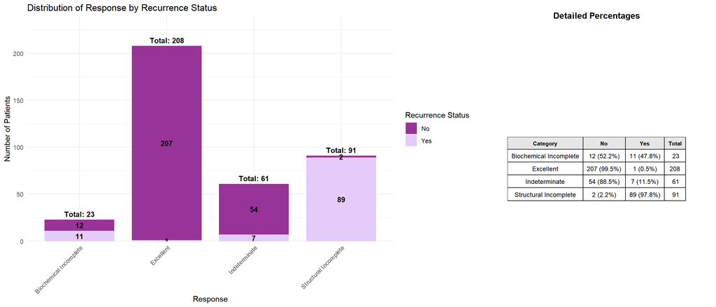

```r
col <- "Response"

  #Preparation for the barplot
  plot_data <- data |>
    group_by(.data[[col]], Recurred) |>  #Group by the modalities of Recurred
    summarise(count = n(), .groups = "drop") |> #we count by modalities of Recurred to build the plot after
    group_by(.data[[col]]) |>#Group by the modalities of the chosen column
    mutate(total = sum(count)) #We add a new column for the sum

  #computation of the totals
  total_data <- data |>
    group_by(.data[[col]]) |>
    summarise(total = n(), .groups = "drop") #Count by couple (col,Recurred) and drop to not

  #Creation of the barplot
  p_bar <- ggplot( plot_data, aes(x = .data[[col]], y = count, fill = Recurred)) +
    geom_bar( stat = "identity", width = 0.8) +
    geom_text(aes(label = count), #To print the total by couple
              position = position_stack(vjust = 0.5),
              fontface = "bold", color = "black", size = 3.5) +
    geom_text(data = total_data, #To print the total by modality
              aes(x = .data[[col]], y = total, label = paste("Total:", total)),
              vjust = -0.5, fontface = "bold", size = 3.5, inherit.aes = FALSE) +
    scale_fill_manual(values = c("No" = "#983399", "Yes"    = "#E4CBF9")) +
    scale_y_continuous(expand = expansion(mult = c(0, 0.15))) +
    theme_minimal() +
    labs(title = paste("Distribution of", col, "by Recurrence Status"),
         x = col,
         y = "Number of Patients",
         fill = "Recurrence Status") +
    theme(axis.text.x = element_text(angle = 45, hjust = 1)) #to tilt the names of the modalities


  #Preparation of the table
  table_df <- data |>
    count(.data[[col]], Recurred) |> #Group col by modality of recurred
    group_by(.data[[col]]) |> #Then group by modality of col
    mutate(pct = n / sum(n) * 100) |> #create a pourcentage
    ungroup() |> #undo the last grouping
    mutate(label = sprintf("%d (%.1f%%)", n, pct)) |> #new var that will be in the table under the form number N then ( then float R then %)
    select(-n, -pct) |> #erase the column we do not need
    pivot_wider(names_from = Recurred, values_from = label, values_fill = "0 (0.0%)") |> #pivote horinzontlly
    left_join(total_data, by = col) |> #add the column in a nice way
    rename(Category = 1, Total = total) #rename the first and last columns

  # Style of the table
  tt <- ttheme_default(
    core = list( bg_params = list(fill = c("white"), col = "black", lwd = 1),
                 fg_params = list(fontsize = 9)
    ), #Set up of the inside of the table
    colhead = list( bg_params = list(fill = "#E6E6E6", col = "black", lwd = 1),
                    fg_params = list(fontsize = 8, fontface = "bold")
    ) #setup of the title colmun
  )

  #Use of function of the package gridExtra to make it look pretty
  p_table <- tableGrob(table_df, rows = NULL, theme = tt)
  title_grob <- textGrob("Detailed Percentages", gp = gpar(fontsize = 12, fontface = "bold"))
  p_table_with_title <- arrangeGrob(title_grob, p_table, heights = c(0.1, 0.9))

  #We print the two plot side by side
  grid.arrange(p_bar, p_table_with_title, ncol = 2, widths = c(2, 1))
```

```r
  cat("\n\n")
```

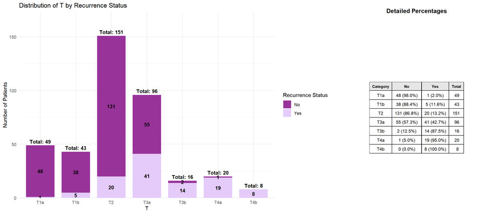

```r
col <- "T"

  #Preparation for the barplot
  plot_data <- data |>
    group_by(.data[[col]], Recurred) |>  #Group by the modalities of Recurred
    summarise(count = n(), .groups = "drop") |> #we count by modalities of Recurred to build the plot after
    group_by(.data[[col]]) |>#Group by the modalities of the chosen column
    mutate(total = sum(count)) #We add a new column for the sum

  #computation of the totals
  total_data <- data |>
    group_by(.data[[col]]) |>
    summarise(total = n(), .groups = "drop") #Count by couple (col,Recurred) and drop to not

  #Creation of the barplot
  p_bar <- ggplot( plot_data, aes(x = .data[[col]], y = count, fill = Recurred)) +
    geom_bar( stat = "identity", width = 0.8) +
    geom_text(aes(label = count), #To print the total by couple
              position = position_stack(vjust = 0.5),
              fontface = "bold", color = "black", size = 3.5) +
    geom_text(data = total_data, #To print the total by modality
              aes(x = .data[[col]], y = total, label = paste("Total:", total)),
              vjust = -0.5, fontface = "bold", size = 3.5, inherit.aes = FALSE) +
    scale_fill_manual(values = c("No" = "#983399", "Yes"    = "#E4CBF9")) +
    scale_y_continuous(expand = expansion(mult = c(0, 0.15))) +
    theme_minimal() +
    labs(title = paste("Distribution of", col, "by Recurrence Status"),
         x = col,
         y = "Number of Patients",
         fill = "Recurrence Status")
    #theme(axis.text.x = element_text(angle = 45, hjust = 1)) #to tilt the names of the modalities


  #Preparation of the table
  table_df <- data |>
    count(.data[[col]], Recurred) |> #Group col by modality of recurred
    group_by(.data[[col]]) |> #Then group by modality of col
    mutate(pct = n / sum(n) * 100) |> #create a pourcentage
    ungroup() |> #undo the last grouping
    mutate(label = sprintf("%d (%.1f%%)", n, pct)) |> #new var that will be in the table under the form number N then ( then float R then %)
    select(-n, -pct) |> #erase the column we do not need
    pivot_wider(names_from = Recurred, values_from = label, values_fill = "0 (0.0%)") |> #pivote horinzontlly
    left_join(total_data, by = col) |> #add the column in a nice way
    rename(Category = 1, Total = total) #rename the first and last columns

  # Style of the table
  tt <- ttheme_default(
    core = list( bg_params = list(fill = c("white"), col = "black", lwd = 1),
                 fg_params = list(fontsize = 9)
    ), #Set up of the inside of the table
    colhead = list( bg_params = list(fill = "#E6E6E6", col = "black", lwd = 1),
                    fg_params = list(fontsize = 8, fontface = "bold")
    ) #setup of the title colmun
  )

  #Use of function of the package gridExtra to make it look pretty
  p_table <- tableGrob(table_df, rows = NULL, theme = tt)
  title_grob <- textGrob("Detailed Percentages", gp = gpar(fontsize = 12, fontface = "bold"))
  p_table_with_title <- arrangeGrob(title_grob, p_table, heights = c(0.1, 0.9))

  #We print the two plot side by side
  grid.arrange(p_bar, p_table_with_title, ncol = 2, widths = c(2, 1))
```

```r
  cat("\n\n")
```

Once again, for the feature `Stage`, there are no data of patient having type III or IV and not having a reccurence. One could assume that this two features `T` and `Stage` are correlated as their interpretation and numbers are very similar.

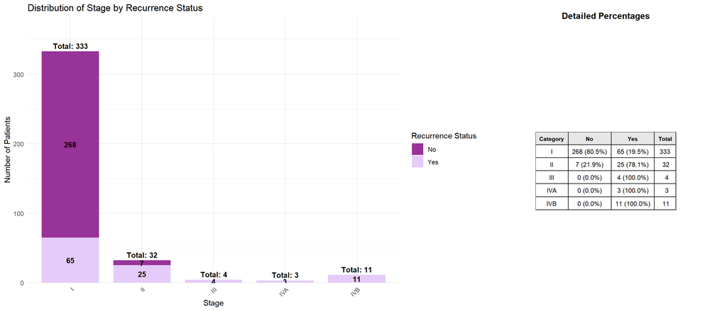

```r
col <- "Stage"

  #Preparation for the barplot
  plot_data <- data |>
    group_by(.data[[col]], Recurred) |>  #Group by the modalities of Recurred
    summarise(count = n(), .groups = "drop") |> #we count by modalities of Recurred to build the plot after
    group_by(.data[[col]]) |>#Group by the modalities of the chosen column
    mutate(total = sum(count)) #We add a new column for the sum

  #computation of the totals
  total_data <- data |>
    group_by(.data[[col]]) |>
    summarise(total = n(), .groups = "drop") #Count by couple (col,Recurred) and drop to not

  #Creation of the barplot
  p_bar <- ggplot( plot_data, aes(x = .data[[col]], y = count, fill = Recurred)) +
    geom_bar( stat = "identity", width = 0.8) +
    geom_text(aes(label = count), #To print the total by couple
              position = position_stack(vjust = 0.5),
              fontface = "bold", color = "black", size = 3.5) +
    geom_text(data = total_data, #To print the total by modality
              aes(x = .data[[col]], y = total, label = paste("Total:", total)),
              vjust = -0.5, fontface = "bold", size = 3.5, inherit.aes = FALSE) +
    scale_fill_manual(values = c("No" = "#983399", "Yes"    = "#E4CBF9")) +
    scale_y_continuous(expand = expansion(mult = c(0, 0.15))) +
    theme_minimal() +
    labs(title = paste("Distribution of", col, "by Recurrence Status"),
         x = col,
         y = "Number of Patients",
         fill = "Recurrence Status") +
    theme(axis.text.x = element_text(angle = 45, hjust = 1)) #to tilt the names of the modalities


  #Preparation of the table
  table_df <- data |>
    count(.data[[col]], Recurred) |> #Group col by modality of recurred
    group_by(.data[[col]]) |> #Then group by modality of col
    mutate(pct = n / sum(n) * 100) |> #create a pourcentage
    ungroup() |> #undo the last grouping
    mutate(label = sprintf("%d (%.1f%%)", n, pct)) |> #new var that will be in the table under the form number N then ( then float R then %)
    select(-n, -pct) |> #erase the column we do not need
    pivot_wider(names_from = Recurred, values_from = label, values_fill = "0 (0.0%)") |> #pivote horinzontlly
    left_join(total_data, by = col) |> #add the column in a nice way
    rename(Category = 1, Total = total) #rename the first and last columns

  # Style of the table
  tt <- ttheme_default(
    core = list( bg_params = list(fill = c("white"), col = "black", lwd = 1),
                 fg_params = list(fontsize = 9)
    ), #Set up of the inside of the table
    colhead = list( bg_params = list(fill = "#E6E6E6", col = "black", lwd = 1),
                    fg_params = list(fontsize = 8, fontface = "bold")
    ) #setup of the title colmun
  )

  #Use of function of the package gridExtra to make it look pretty
  p_table <- tableGrob(table_df, rows = NULL, theme = tt)
  title_grob <- textGrob("Detailed Percentages", gp = gpar(fontsize = 12, fontface = "bold"))
  p_table_with_title <- arrangeGrob(title_grob, p_table, heights = c(0.1, 0.9))

  #We print the two plot side by side
  grid.arrange(p_bar, p_table_with_title, ncol = 2, widths = c(2, 1))
```

```r
  cat("\n\n")
```

Here is an other example, but with a different interpretation. In this case we do not observe modalities with a clear link like we saw for the feature `Response`. However, one can still conclude that more Female had a first Thyroid cancer. And that in percent, women tend to have less recurrence than men: only 21.2%. for female against 59.2% for male. This is why it is important to draw the table with percentage, as one could be misled by the numbers alone. We cannot assume anything clearly from this feature at this point and will wait for the model to show if the gender has a role in the recurrence.

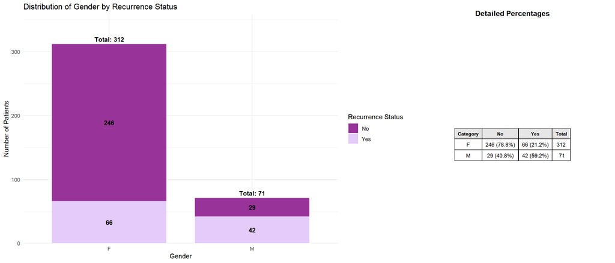

```r
col <- "Gender"

  #Preparation for the barplot
  plot_data <- data |>
    group_by(.data[[col]], Recurred) |>  #Group by the modalities of Recurred
    summarise(count = n(), .groups = "drop") |> #we count by modalities of Recurred to build the plot after
    group_by(.data[[col]]) |>#Group by the modalities of the chosen column
    mutate(total = sum(count)) #We add a new column for the sum

  #computation of the totals
  total_data <- data |>
    group_by(.data[[col]]) |>
    summarise(total = n(), .groups = "drop") #Count by couple (col,Recurred) and drop to not

  #Creation of the barplot
  p_bar <- ggplot( plot_data, aes(x = .data[[col]], y = count, fill = Recurred)) +
    geom_bar( stat = "identity", width = 0.8) +
    geom_text(aes(label = count), #To print the total by couple
              position = position_stack(vjust = 0.5),
              fontface = "bold", color = "black", size = 3.5) +
    geom_text(data = total_data, #To print the total by modality
              aes(x = .data[[col]], y = total, label = paste("Total:", total)),
              vjust = -0.5, fontface = "bold", size = 3.5, inherit.aes = FALSE) +
    scale_fill_manual(values = c("No" = "#983399", "Yes"    = "#E4CBF9")) +
    scale_y_continuous(expand = expansion(mult = c(0, 0.15))) +
    theme_minimal() +
    labs(title = paste("Distribution of", col, "by Recurrence Status"),
         x = col,
         y = "Number of Patients",
         fill = "Recurrence Status")
    #theme(axis.text.x = element_text(angle = 45, hjust = 1)) #to tilt the names of the modalities


  #Preparation of the table
  table_df <- data |>
    count(.data[[col]], Recurred) |> #Group col by modality of recurred
    group_by(.data[[col]]) |> #Then group by modality of col
    mutate(pct = n / sum(n) * 100) |> #create a pourcentage
    ungroup() |> #undo the last grouping
    mutate(label = sprintf("%d (%.1f%%)", n, pct)) |> #new var that will be in the table under the form number N then ( then float R then %)
    select(-n, -pct) |> #erase the column we do not need
    pivot_wider(names_from = Recurred, values_from = label, values_fill = "0 (0.0%)") |> #pivote horinzontlly
    left_join(total_data, by = col) |> #add the column in a nice way
    rename(Category = 1, Total = total) #rename the first and last columns

  # Style of the table
  tt <- ttheme_default(
    core = list( bg_params = list(fill = c("white"), col = "black", lwd = 1),
                 fg_params = list(fontsize = 9)
    ), #Set up of the inside of the table
    colhead = list( bg_params = list(fill = "#E6E6E6", col = "black", lwd = 1),
                    fg_params = list(fontsize = 8, fontface = "bold")
    ) #setup of the title colmun
  )

  #Use of function of the package gridExtra to make it look pretty
  p_table <- tableGrob(table_df, rows = NULL, theme = tt)
  title_grob <- textGrob("Detailed Percentages", gp = gpar(fontsize = 12, fontface = "bold"))
  p_table_with_title <- arrangeGrob(title_grob, p_table, heights = c(0.1, 0.9))

  #We print the two plot side by side
  grid.arrange(p_bar, p_table_with_title, ncol = 2, widths = c(2, 1))
```

```r
  cat("\n\n")
```

One could also introduce an another figure which prints the barplot but a scaled version of it. Each bar has the same height and is broken down by percentage.

```r
for (col in cat_var_names) {

  pourcent_plot <- ggplot(data, aes(x = .data[[col]], fill = Recurred)) +
    geom_bar(position = "fill", width = 0.7) + #position = "fill" to give them this height
    scale_y_continuous(labels = scales::percent) + #y axis in pourcent
    scale_fill_manual(values = c("No" = "#983399", "Yes" = "#E4CBF9")) +
    theme_minimal() +
    labs(title = paste("Proportion of Recurrence by", col),
         x = col,
         y = "Proportion (%)",
         fill = "Recurred Status") +
    theme(axis.text.x = element_text(angle = 45, hjust = 1))

  print(pourcent_plot)
}
```

Here is a relevant example for the feature `Gender`. In this version, on can directly observe that male have higher chances at thyroid cancer recurrence.

```r
col <- "Gender"

  pourcent_plot <- ggplot(data, aes(x = .data[[col]], fill = Recurred)) +
    geom_bar(position = "fill", width = 0.7) + #position = "fill" to give them this height
    scale_y_continuous(labels = scales::percent) + #y axis in pourcent
    scale_fill_manual(values = c("No" = "#983399", "Yes" = "#E4CBF9")) +
    theme_minimal() +
    labs(title = paste("Proportion of Recurrence by", col),
         x = col,
         y = "Proportion (%)",
         fill = "Recurred Status") +
    theme(axis.text.x = element_text(angle = 45, hjust = 1))

  ggplotly(pourcent_plot)
```

[interactive chart not shown]

# 2. Preprocessing

## 2.1. Data Engineering

### 2.1.1. Correlation

For this project, we will use models that could require variable selection. Therefore we perform correlations tests using the method of Cramer’s V with the `rcompanion` package.

```r
cat_var_names <- data |> select(-Age) |> names()
cat_var <- data |> select(-Age)
#cat_var <- data |> select(where(is.factor))

#Computation of the matrix
n <- length(cat_var_names)
cramer_matrix <- matrix(nrow = n, ncol = n, dimnames = list(cat_var_names, cat_var_names))
for (i in 1:n) {
  for (j in 1:n) {
    #Computation for each couple (i,j) of categorical features
    cramer_matrix[i, j] <- cramerV(data[[cat_var_names[i]]], data[[cat_var_names[j]]])
  }
}

melted_cramer <- melt(cramer_matrix) #Change from a matrix from to a 'long' form in order to be used by ggplot

#Construction of the plot of the matrix
cramer_plot <- ggplot(melted_cramer, aes(Var1, Var2, fill = value)) +
  geom_tile() +
  geom_text(aes(label = round(value, 2)), color = "black", size = 3) +
  scale_fill_gradient2(low = "white", high = "#983399", limit = c(0, 1), name = "Cramer's V") + #creation of a radient of colours
  theme_minimal() +
  theme(axis.text.x = element_text(angle = 45, hjust = 1)) +
  labs(title = "Correlation matrix by Cramer's V",
       x = "", y = "")

ggplotly(cramer_plot)
```

[interactive chart not shown]

We then fix a threshold of 0.7 above which we consider two features to be strongly correlated. This allows us to identify three couples of features:

```r
CORRELATION_THRESHOLD <- 0.7
n <- nrow(cramer_matrix)

for (i in 1:(n - 1)) {
  for (j in (i + 1):n) {

    val <- cramer_matrix[i, j]
    if (!is.na(val) && val > CORRELATION_THRESHOLD) {
      var1 <- rownames(cramer_matrix)[i]
      var2 <- colnames(cramer_matrix)[j]
      cat(sprintf("The variables %s and %s are strongly correlated (Cramer's V = %.2f)\n",
                  var1, var2, val))
    }
  }
}
```

```
## The variables Risk and Recurred are strongly correlated (Cramer's V = 0.74)
## The variables M and Stage are strongly correlated (Cramer's V = 0.76)
## The variables Response and Recurred are strongly correlated (Cramer's V = 0.90)
```

Response will be removed from the dataset as it creates data leakage. Moreover, either `M` or `Stage` need to be removed as it would create noise in models to which some methods are sensitive. On a medical point of view it is more interesting to keep `M`, `N` and `T` and to let go of in order to avoid multicolinearity. However, even if `Risk` and `Recurred` are strongly correlated, we keep it as it is a feature given by doctors before knowing the result. The correlation especially means that the doctors are doing a good job at estimating the risk of cancer recurrence. Thus, it as it is a very good indicator of the classification of our patients.

### 2.1.2. Duplicate cheking

We identify several lines that are identical, we will consider them corresponding to two patients having the same characteristics as it is highly probable to have such occurrences in real life.

```r
nb_dupliactes <- sum(duplicated(data))
cat("Number of duplicated lines:", nb_dupliactes, "\n")
```

```
## Number of duplicated lines: 19
```

### 2.1.3. Missing values

When it comes to missing values, we must decide whether to remove the affected rows or to replace the missing entries with a mean, a median, or another deterministic value. However, this dataset is complete whichi simplifies the consideration. Here are two different way of checking, first with a visual plot, then with a function.

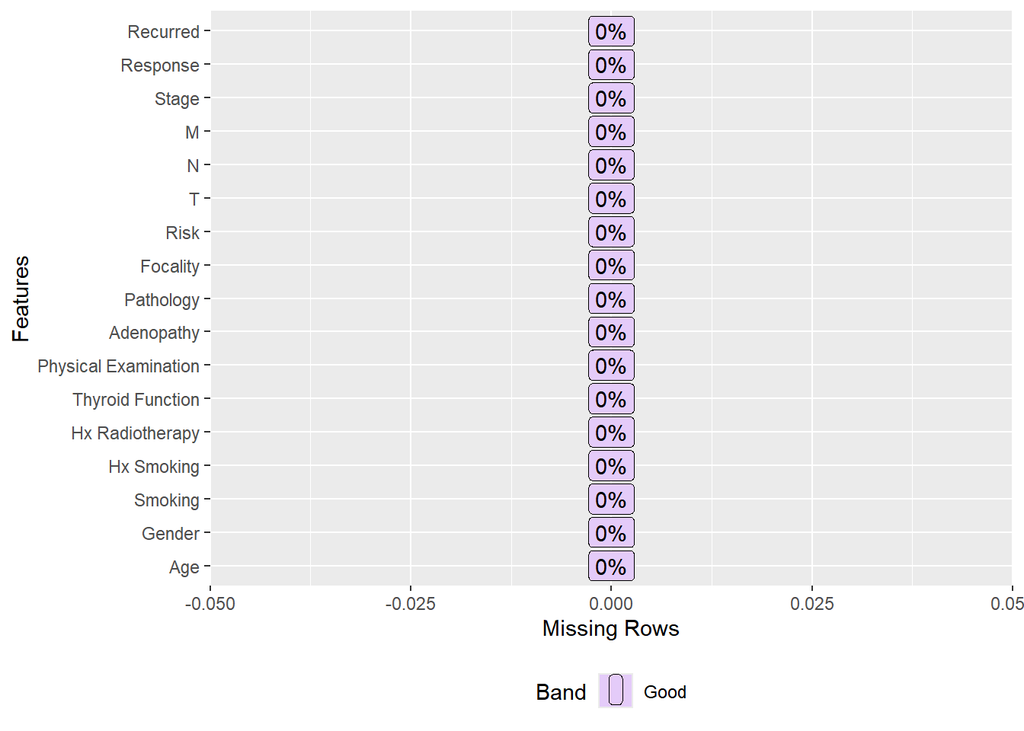

```r
plot_missing(data, group_color = list("Good" = "#E4CBF9", "OK" = "#E6AB02", "Bad" = "#D95F02", "Remove" = "#E41A1C"))
```

```r
nb_missing <- sum(is.na(data))
cat("Number of missing data:", nb_missing, "\n")
```

```
## Number of missing data: 0
```

### 2.1.4. Outliers

As there is only one numerical features, the only possible source of outliers is the feature `Age`.Outliers are extreme observations that deviate from the general pattern of the data, and we use boxplots as it provides a simple way to visualize and detect these unusual values. The next plot presents the boxplot of the feature `Age`. Every observation seems to be located between the whiskers so no significant outliers.

```r
outlier_plot <- ggplot(data, aes(y = Age, x = "Global")) +
  geom_boxplot(width = 0.1, fill = "#E4CBF9", alpha = 0.7, outlier.alpha = 0) +
  geom_jitter(width = 0.2, size = 1, color = "#983399", alpha = 1) +
  theme_minimal() +
  labs(title = "Outlier detection for the feature Age",
       y = "Age",
       x = "")

ggplotly(outlier_plot)
```

[interactive chart not shown]

To verify this intuition we perform a test with the values of Inter-Quantile Range. It confirms that there are no outliers in the dataset.

```r
Q1 <- quantile(data$Age, 0.25)
Q3 <- quantile(data$Age, 0.75)
IQR <- Q3 - Q1

lower_bound <- Q1 - 1.5 * IQR
upper_bound <- Q3 + 1.5 * IQR

outliers <- data |> filter(Age < lower_bound | Age > upper_bound)
cat("Number of outliers detected for the feature 'Age':", nrow(outliers))
```

```
## Number of outliers detected for the feature 'Age': 0
```

## 2.2. Data sampling

For the previous subsection, we conclude that we will consider two datasets: the complete one (`data`) we will be using for models which do not require variable selection and an other one with variable selection `data_selected`).

We sample our dataset with a 80%/20% train/test split using stratification on the target variable as it is unbalanced.

```r
set.seed(2711)

data_split <- initial_split(data, prop = 0.8, strata = Recurred)

train_data <- training(data_split)
test_data  <- testing(data_split)

cat("Train set size:", nrow(train_data), "\n")
```

```
## Train set size: 306
```

```r
cat("Test set size:", nrow(test_data), "\n")
```

```
## Test set size: 77
```

We verify that the proportions in the train and test sets are the same.

```r
prop.table(table(train_data$Recurred))
```

```
##
##        No       Yes
## 0.7189542 0.2810458
```

```r
prop.table(table(test_data$Recurred))
```

```
##
##        No       Yes
## 0.7142857 0.2857143
```

We construct the train and test sets for the dataset with variable selection.

```r
train_data_selected <- train_data |>
  select(-Stage, -Response)

test_data_selected <- test_data |>
  select(-Stage, -Response)
```

## 2.3. Features engineering

### 2.3.1. One-hot encoding

In the section we create binary features which are the one-hot encoding of every categorical features as they will be useful for the models built in this project. For the features with two modalities, we create a binary version in which one of the modalities is replaced by 1 and the other by 0. First we do it on the target variable.

```r
train_data_Binary <- train_data |>
  mutate(Recurred_Binary = ifelse(Recurred == "Yes", 1, 0))

head(train_data_Binary |> select(Recurred, Recurred_Binary), 230)
```

| Recurred | Recurred_Binary |
| --- | --- |
| No | 0 |
| No | 0 |
| No | 0 |
| No | 0 |
| No | 0 |
| No | 0 |
| No | 0 |
| No | 0 |
| No | 0 |
| No | 0 |

[output cut: 220 more lines]

Then, we do the one-hot-encoding on the other bimodal features. We create a binary version in which one of the modalities is replaced by `1` and the other by `0`.

```r
train_data_Binary <- train_data_Binary |>
  mutate(Gender_Binary = ifelse(Gender == "F", 1, 0)) |>
  mutate(Smoking_Binary = ifelse(Smoking == "Yes", 1, 0)) |>
  mutate(Hx_Smoking_Binary = ifelse(`Hx Smoking` == "Yes", 1, 0)) |>
  mutate(Hx_Radiotherapy_Binary = ifelse(`Hx Radiotherapy` == "Yes", 1, 0)) |>
  mutate(Focality_Binary = ifelse(Focality == "Uni-Focal", 1, 0)) |>
  mutate(M_Binary = ifelse(M == "M1", 1, 0))
```

Regarding multi-modal features, we explain the functionning of an example. The feature `Risk` has three initial modalities. We create two new binary features `Risk_High_Binary` which is equal to `1` when the observation has a high risk and `0` otherwise, and `Risk_Intermediate_Binary` which is equal to `1` when the observation has an intermediate risk and `0` otherwise. We do not need a feature `Risk_Low_Binary` as this case is represented by both binary risk features being equal to `0`.

```r
train_data_Binary <- train_data_Binary |>
  #`Thyroid Function`
  mutate(Thyroid_Function_Euthyroid_Binary = ifelse(`Thyroid Function` == "Euthyroid", 1, 0)) |>
  mutate(Thyroid_Function_Clinical_Hyperthyroidism_Binary = ifelse(`Thyroid Function` == "Clinical Hyperthyroidism", 1, 0)) |>
  mutate(Thyroid_Function_Clinical_Hypothyroidism_Binary = ifelse(`Thyroid Function` == "Clinical Hypothyroidism", 1, 0)) |>
  mutate(Thyroid_Function_Subclinical_Hypothyroidism_Binary = ifelse(`Thyroid Function` == "Subclinical Hypothyroidism", 1, 0)) |>
  #`Physical Examination`
  mutate(Physical_Examination_Single_nodular_goiter_left_Binary = ifelse(`Physical Examination` == "Single nodular goiter-left", 1, 0)) |>
  mutate(Physical_Examination_Multinodular_goiter_Binary = ifelse(`Physical Examination` == "Multinodular goiter", 1, 0)) |>
  mutate(Physical_Examination_Single_nodular_goiter_right_Binary = ifelse(`Physical Examination` == "Single nodular goiter-right", 1, 0)) |>
  mutate(Physical_Examination_Normal_Binary = ifelse(`Physical Examination` == "Normal", 1, 0)) |>
  #Adenopathy
  mutate(Adenopathy_No_Binary = ifelse(Adenopathy == "No", 1, 0)) |>
  mutate(Adenopathy_Right_Binary = ifelse(Adenopathy == "Right", 1, 0)) |>
  mutate(Adenopathy_Left_Binary = ifelse(Adenopathy == "Left", 1, 0)) |>
  mutate(Adenopathy_Bilateral_Binary = ifelse(Adenopathy == "Bilateral", 1, 0)) |>
  mutate(Adenopathy_Posterior_Binary = ifelse(Adenopathy == "Posterior", 1, 0)) |>
  #Pathology
  mutate(Pathology_Papillary_Binary = ifelse(Pathology == "Papillary", 1, 0)) |>
  mutate(Pathology_Micropapillary_Binary = ifelse(Pathology == "Micropapillary", 1, 0)) |>
  mutate(Pathology_Follicular_Binary = ifelse(Pathology == "Follicular", 1, 0)) |>
  #Risk
  mutate(Risk_High_Binary = ifelse(Risk == "High", 1, 0)) |>
  mutate(Risk_Intermediate_Binary = ifelse(Risk == "Intermediate", 1, 0)) |>
  #T
  mutate(T_T1a_Binary = ifelse(T == "T1a", 1, 0)) |>
  mutate(T_T1b_Binary = ifelse(T == "T1b", 1, 0)) |>
  mutate(T_T2_Binary = ifelse(T == "T2", 1, 0)) |>
  mutate(T_T3a_Binary = ifelse(T == "T3a", 1, 0)) |>
  mutate(T_T3b_Binary = ifelse(T == "T3b", 1, 0)) |>
  mutate(T_T4a_Binary = ifelse(T == "T4a", 1, 0)) |>
  #N
  mutate(N_N0_Binary = ifelse(N == "N0", 1, 0)) |>
  mutate(N_N1a_Binary = ifelse(N == "N1a", 1, 0)) |>
  #Stage
  mutate(Stage_I_Binary = ifelse(Stage == "I", 1, 0)) |>
  mutate(Stage_II_Binary = ifelse(Stage == "II", 1, 0)) |>
  mutate(Stage_III_Binary = ifelse(Stage == "III", 1, 0)) |>
  mutate(Stage_IVA_Binary = ifelse(Stage == "IVA", 1, 0)) |>
  #Response
  mutate(Response_Excellent_Binary = ifelse(Response == "Excellent", 1, 0)) |>
  mutate(Response_Indeterminate_Binary = ifelse(Response == "Indeterminate", 1, 0)) |>
  mutate(Response_Biochemical_Incomplete_Binary = ifelse(Response == "Biochemical Incomplete", 1, 0))
```

Finally, we delete the initial features to keep only the binary ones.

```r
train_data_Binary <- train_data_Binary |>
  select(-Gender, -Smoking, -`Hx Smoking`, -`Hx Radiotherapy`, -`Thyroid Function`, -`Physical Examination`, -Adenopathy, -Pathology, -Focality, -Risk, -T, -N, -M, -Stage, -Response, -Recurred)
```

Here is an insight of this new train set.

```r
head(train_data_Binary, 10) |> rmarkdown::paged_table()
```

| Age | Recurred_Binary | Gender_Binary | Smoking_Binary | Hx_Smoking_Binary | Hx_Radiotherapy_Binary | Focality_Binary | M_Binary | Thyroid_Function_Euthyroid_Binary | Thyroid_Function_Clinical_Hyperthyroidism_Binary | Thyroid_Function_Clinical_Hypothyroidism_Binary | Thyroid_Function_Subclinical_Hypothyroidism_Binary | Physical_Examination_Single_nodular_goiter_left_Binary | Physical_Examination_Multinodular_goiter_Binary | Physical_Examination_Single_nodular_goiter_right_Binary | Physical_Examination_Normal_Binary | Adenopathy_No_Binary | Adenopathy_Right_Binary | Adenopathy_Left_Binary | Adenopathy_Bilateral_Binary | Adenopathy_Posterior_Binary | Pathology_Papillary_Binary | Pathology_Micropapillary_Binary | Pathology_Follicular_Binary | Risk_High_Binary | Risk_Intermediate_Binary | T_T1a_Binary | T_T1b_Binary | T_T2_Binary | T_T3a_Binary | … |
| --- | --- | --- | --- | --- | --- | --- | --- | --- | --- | --- | --- | --- | --- | --- | --- | --- | --- | --- | --- | --- | --- | --- | --- | --- | --- | --- | --- | --- | --- | --- |
| 34 | 0 | 1 | 0 | 1 | 0 | 1 | 0 | 1 | 0 | 0 | 0 | 0 | 1 | 0 | 0 | 1 | 0 | 0 | 0 | 0 | 0 | 1 | 0 | 0 | 0 | 1 | 0 | 0 | 0 | … |
| 30 | 0 | 1 | 0 | 0 | 0 | 1 | 0 | 1 | 0 | 0 | 0 | 0 | 0 | 1 | 0 | 1 | 0 | 0 | 0 | 0 | 0 | 1 | 0 | 0 | 0 | 1 | 0 | 0 | 0 | … |
| 62 | 0 | 1 | 0 | 0 | 0 | 1 | 0 | 1 | 0 | 0 | 0 | 0 | 0 | 1 | 0 | 1 | 0 | 0 | 0 | 0 | 0 | 1 | 0 | 0 | 0 | 1 | 0 | 0 | 0 | … |
| 52 | 0 | 0 | 1 | 0 | 0 | 0 | 0 | 1 | 0 | 0 | 0 | 0 | 1 | 0 | 0 | 1 | 0 | 0 | 0 | 0 | 0 | 1 | 0 | 0 | 0 | 1 | 0 | 0 | 0 | … |
| 41 | 0 | 1 | 0 | 1 | 0 | 1 | 0 | 0 | 1 | 0 | 0 | 0 | 0 | 1 | 0 | 1 | 0 | 0 | 0 | 0 | 0 | 1 | 0 | 0 | 0 | 1 | 0 | 0 | 0 | … |
| 46 | 0 | 1 | 0 | 0 | 0 | 1 | 0 | 1 | 0 | 0 | 0 | 0 | 0 | 1 | 0 | 1 | 0 | 0 | 0 | 0 | 0 | 1 | 0 | 0 | 0 | 1 | 0 | 0 | 0 | … |
| 51 | 0 | 1 | 0 | 0 | 0 | 1 | 0 | 1 | 0 | 0 | 0 | 0 | 0 | 1 | 0 | 1 | 0 | 0 | 0 | 0 | 0 | 1 | 0 | 0 | 0 | 1 | 0 | 0 | 0 | … |
| 40 | 0 | 1 | 0 | 0 | 0 | 1 | 0 | 1 | 0 | 0 | 0 | 0 | 0 | 1 | 0 | 1 | 0 | 0 | 0 | 0 | 0 | 1 | 0 | 0 | 0 | 1 | 0 | 0 | 0 | … |
| 59 | 0 | 1 | 0 | 0 | 0 | 1 | 0 | 1 | 0 | 0 | 0 | 1 | 0 | 0 | 0 | 1 | 0 | 0 | 0 | 0 | 0 | 1 | 0 | 0 | 0 | 1 | 0 | 0 | 0 | … |
| 49 | 0 | 1 | 0 | 0 | 0 | 1 | 0 | 1 | 0 | 0 | 0 | 0 | 1 | 0 | 0 | 1 | 0 | 0 | 0 | 0 | 0 | 1 | 0 | 0 | 0 | 1 | 0 | 0 | 0 | … |

We need to do the one-hot-encoding for the train set with variable selection. We could do the all process again but here we only need to delete the binary feature corresponding to the feature which were deleted for this set: `Stage` and `Response`.

```r
train_data_selected_Binary <- train_data_Binary |>
  select(-Stage_I_Binary, -Stage_II_Binary, -Stage_III_Binary, -Stage_IVA_Binary) |>
  select(-Response_Excellent_Binary, -Response_Indeterminate_Binary, -Response_Biochemical_Incomplete_Binary)

head(train_data_selected_Binary, 10) |> rmarkdown::paged_table()
```

| Age | Recurred_Binary | Gender_Binary | Smoking_Binary | Hx_Smoking_Binary | Hx_Radiotherapy_Binary | Focality_Binary | M_Binary | Thyroid_Function_Euthyroid_Binary | Thyroid_Function_Clinical_Hyperthyroidism_Binary | Thyroid_Function_Clinical_Hypothyroidism_Binary | Thyroid_Function_Subclinical_Hypothyroidism_Binary | Physical_Examination_Single_nodular_goiter_left_Binary | Physical_Examination_Multinodular_goiter_Binary | Physical_Examination_Single_nodular_goiter_right_Binary | Physical_Examination_Normal_Binary | Adenopathy_No_Binary | Adenopathy_Right_Binary | Adenopathy_Left_Binary | Adenopathy_Bilateral_Binary | Adenopathy_Posterior_Binary | Pathology_Papillary_Binary | Pathology_Micropapillary_Binary | Pathology_Follicular_Binary | Risk_High_Binary | Risk_Intermediate_Binary | T_T1a_Binary | T_T1b_Binary | T_T2_Binary | T_T3a_Binary | … |
| --- | --- | --- | --- | --- | --- | --- | --- | --- | --- | --- | --- | --- | --- | --- | --- | --- | --- | --- | --- | --- | --- | --- | --- | --- | --- | --- | --- | --- | --- | --- |
| 34 | 0 | 1 | 0 | 1 | 0 | 1 | 0 | 1 | 0 | 0 | 0 | 0 | 1 | 0 | 0 | 1 | 0 | 0 | 0 | 0 | 0 | 1 | 0 | 0 | 0 | 1 | 0 | 0 | 0 | … |
| 30 | 0 | 1 | 0 | 0 | 0 | 1 | 0 | 1 | 0 | 0 | 0 | 0 | 0 | 1 | 0 | 1 | 0 | 0 | 0 | 0 | 0 | 1 | 0 | 0 | 0 | 1 | 0 | 0 | 0 | … |
| 62 | 0 | 1 | 0 | 0 | 0 | 1 | 0 | 1 | 0 | 0 | 0 | 0 | 0 | 1 | 0 | 1 | 0 | 0 | 0 | 0 | 0 | 1 | 0 | 0 | 0 | 1 | 0 | 0 | 0 | … |
| 52 | 0 | 0 | 1 | 0 | 0 | 0 | 0 | 1 | 0 | 0 | 0 | 0 | 1 | 0 | 0 | 1 | 0 | 0 | 0 | 0 | 0 | 1 | 0 | 0 | 0 | 1 | 0 | 0 | 0 | … |
| 41 | 0 | 1 | 0 | 1 | 0 | 1 | 0 | 0 | 1 | 0 | 0 | 0 | 0 | 1 | 0 | 1 | 0 | 0 | 0 | 0 | 0 | 1 | 0 | 0 | 0 | 1 | 0 | 0 | 0 | … |
| 46 | 0 | 1 | 0 | 0 | 0 | 1 | 0 | 1 | 0 | 0 | 0 | 0 | 0 | 1 | 0 | 1 | 0 | 0 | 0 | 0 | 0 | 1 | 0 | 0 | 0 | 1 | 0 | 0 | 0 | … |
| 51 | 0 | 1 | 0 | 0 | 0 | 1 | 0 | 1 | 0 | 0 | 0 | 0 | 0 | 1 | 0 | 1 | 0 | 0 | 0 | 0 | 0 | 1 | 0 | 0 | 0 | 1 | 0 | 0 | 0 | … |
| 40 | 0 | 1 | 0 | 0 | 0 | 1 | 0 | 1 | 0 | 0 | 0 | 0 | 0 | 1 | 0 | 1 | 0 | 0 | 0 | 0 | 0 | 1 | 0 | 0 | 0 | 1 | 0 | 0 | 0 | … |
| 59 | 0 | 1 | 0 | 0 | 0 | 1 | 0 | 1 | 0 | 0 | 0 | 1 | 0 | 0 | 0 | 1 | 0 | 0 | 0 | 0 | 0 | 1 | 0 | 0 | 0 | 1 | 0 | 0 | 0 | … |
| 49 | 0 | 1 | 0 | 0 | 0 | 1 | 0 | 1 | 0 | 0 | 0 | 0 | 1 | 0 | 0 | 1 | 0 | 0 | 0 | 0 | 0 | 1 | 0 | 0 | 0 | 1 | 0 | 0 | 0 | … |

We also need to perform one-hot-encoding on the test set. Here, we use the exact same code as for the train set.

```r
test_data_Binary <- test_data |>
  #TARGET
  mutate(Recurred_Binary = ifelse(Recurred == "Yes", 1, 0)) |>
  #BIMODAL
  mutate(Gender_Binary = ifelse(Gender == "F", 1, 0)) |>
  mutate(Smoking_Binary = ifelse(Smoking == "Yes", 1, 0)) |>
  mutate(Hx_Smoking_Binary = ifelse(`Hx Smoking` == "Yes", 1, 0)) |>
  mutate(Hx_Radiotherapy_Binary = ifelse(`Hx Radiotherapy` == "Yes", 1, 0)) |>
  mutate(Focality_Binary = ifelse(Focality == "Uni-Focal", 1, 0)) |>
  mutate(M_Binary = ifelse(M == "M1", 1, 0)) |>
  #MULTIMODAL
  #`Thyroid Function`
  mutate(Thyroid_Function_Euthyroid_Binary = ifelse(`Thyroid Function` == "Euthyroid", 1, 0)) |>
  mutate(Thyroid_Function_Clinical_Hyperthyroidism_Binary = ifelse(`Thyroid Function` == "Clinical Hyperthyroidism", 1, 0)) |>
  mutate(Thyroid_Function_Clinical_Hypothyroidism_Binary = ifelse(`Thyroid Function` == "Clinical Hypothyroidism", 1, 0)) |>
  mutate(Thyroid_Function_Subclinical_Hypothyroidism_Binary = ifelse(`Thyroid Function` == "Subclinical Hypothyroidism", 1, 0)) |>
  #`Physical Examination`
  mutate(Physical_Examination_Single_nodular_goiter_left_Binary = ifelse(`Physical Examination` == "Single nodular goiter-left", 1, 0)) |>
  mutate(Physical_Examination_Multinodular_goiter_Binary = ifelse(`Physical Examination` == "Multinodular goiter", 1, 0)) |>
  mutate(Physical_Examination_Single_nodular_goiter_right_Binary = ifelse(`Physical Examination` == "Single nodular goiter-right", 1, 0)) |>
  mutate(Physical_Examination_Normal_Binary = ifelse(`Physical Examination` == "Normal", 1, 0)) |>
  #Adenopathy
  mutate(Adenopathy_No_Binary = ifelse(Adenopathy == "No", 1, 0)) |>
  mutate(Adenopathy_Right_Binary = ifelse(Adenopathy == "Right", 1, 0)) |>
  mutate(Adenopathy_Left_Binary = ifelse(Adenopathy == "Left", 1, 0)) |>
  mutate(Adenopathy_Bilateral_Binary = ifelse(Adenopathy == "Bilateral", 1, 0)) |>
  mutate(Adenopathy_Posterior_Binary = ifelse(Adenopathy == "Posterior", 1, 0)) |>
  #Pathology
  mutate(Pathology_Papillary_Binary = ifelse(Pathology == "Papillary", 1, 0)) |>
  mutate(Pathology_Micropapillary_Binary = ifelse(Pathology == "Micropapillary", 1, 0)) |>
  mutate(Pathology_Follicular_Binary = ifelse(Pathology == "Follicular", 1, 0)) |>
  #Risk
  mutate(Risk_High_Binary = ifelse(Risk == "High", 1, 0)) |>
  mutate(Risk_Intermediate_Binary = ifelse(Risk == "Intermediate", 1, 0)) |>
  #T
  mutate(T_T1a_Binary = ifelse(T == "T1a", 1, 0)) |>
  mutate(T_T1b_Binary = ifelse(T == "T1b", 1, 0)) |>
  mutate(T_T2_Binary = ifelse(T == "T2", 1, 0)) |>
  mutate(T_T3a_Binary = ifelse(T == "T3a", 1, 0)) |>
  mutate(T_T3b_Binary = ifelse(T == "T3b", 1, 0)) |>
  mutate(T_T4a_Binary = ifelse(T == "T4a", 1, 0)) |>
  #N
  mutate(N_N0_Binary = ifelse(N == "N0", 1, 0)) |>
  mutate(N_N1a_Binary = ifelse(N == "N1a", 1, 0)) |>
  #Stage
  mutate(Stage_I_Binary = ifelse(Stage == "I", 1, 0)) |>
  mutate(Stage_II_Binary = ifelse(Stage == "II", 1, 0)) |>
  mutate(Stage_III_Binary = ifelse(Stage == "III", 1, 0)) |>
  mutate(Stage_IVA_Binary = ifelse(Stage == "IVA", 1, 0)) |>
  #Response
  mutate(Response_Excellent_Binary = ifelse(Response == "Excellent", 1, 0)) |>
  mutate(Response_Indeterminate_Binary = ifelse(Response == "Indeterminate", 1, 0)) |>
  mutate(Response_Biochemical_Incomplete_Binary = ifelse(Response == "Biochemical Incomplete", 1, 0)) |>
  #DELETE INITIAL
  select(-Gender, -Smoking, -`Hx Smoking`, -`Hx Radiotherapy`, -`Thyroid Function`, -`Physical Examination`, -Adenopathy, -Pathology, -Focality, -Risk, -T, -N, -M, -Stage, -Response, -Recurred)

head(test_data_Binary, 10) |> rmarkdown::paged_table()
```

| Age | Recurred_Binary | Gender_Binary | Smoking_Binary | Hx_Smoking_Binary | Hx_Radiotherapy_Binary | Focality_Binary | M_Binary | Thyroid_Function_Euthyroid_Binary | Thyroid_Function_Clinical_Hyperthyroidism_Binary | Thyroid_Function_Clinical_Hypothyroidism_Binary | Thyroid_Function_Subclinical_Hypothyroidism_Binary | Physical_Examination_Single_nodular_goiter_left_Binary | Physical_Examination_Multinodular_goiter_Binary | Physical_Examination_Single_nodular_goiter_right_Binary | Physical_Examination_Normal_Binary | Adenopathy_No_Binary | Adenopathy_Right_Binary | Adenopathy_Left_Binary | Adenopathy_Bilateral_Binary | Adenopathy_Posterior_Binary | Pathology_Papillary_Binary | Pathology_Micropapillary_Binary | Pathology_Follicular_Binary | Risk_High_Binary | Risk_Intermediate_Binary | T_T1a_Binary | T_T1b_Binary | T_T2_Binary | T_T3a_Binary | … |
| --- | --- | --- | --- | --- | --- | --- | --- | --- | --- | --- | --- | --- | --- | --- | --- | --- | --- | --- | --- | --- | --- | --- | --- | --- | --- | --- | --- | --- | --- | --- |
| 27 | 0 | 1 | 0 | 0 | 0 | 1 | 0 | 1 | 0 | 0 | 0 | 1 | 0 | 0 | 0 | 1 | 0 | 0 | 0 | 0 | 0 | 1 | 0 | 0 | 0 | 1 | 0 | 0 | 0 | … |
| 62 | 0 | 1 | 0 | 0 | 0 | 0 | 0 | 1 | 0 | 0 | 0 | 0 | 1 | 0 | 0 | 1 | 0 | 0 | 0 | 0 | 0 | 1 | 0 | 0 | 0 | 1 | 0 | 0 | 0 | … |
| 75 | 0 | 1 | 0 | 0 | 0 | 1 | 0 | 1 | 0 | 0 | 0 | 0 | 0 | 1 | 0 | 1 | 0 | 0 | 0 | 0 | 0 | 1 | 0 | 0 | 0 | 1 | 0 | 0 | 0 | … |
| 42 | 0 | 1 | 0 | 0 | 0 | 1 | 0 | 1 | 0 | 0 | 0 | 0 | 0 | 1 | 0 | 1 | 0 | 0 | 0 | 0 | 0 | 1 | 0 | 0 | 0 | 1 | 0 | 0 | 0 | … |
| 44 | 0 | 1 | 0 | 0 | 0 | 1 | 0 | 1 | 0 | 0 | 0 | 1 | 0 | 0 | 0 | 1 | 0 | 0 | 0 | 0 | 0 | 1 | 0 | 0 | 0 | 1 | 0 | 0 | 0 | … |
| 60 | 0 | 1 | 0 | 0 | 0 | 0 | 0 | 1 | 0 | 0 | 0 | 0 | 1 | 0 | 0 | 1 | 0 | 0 | 0 | 0 | 0 | 1 | 0 | 0 | 0 | 1 | 0 | 0 | 0 | … |
| 37 | 0 | 1 | 0 | 1 | 0 | 1 | 0 | 0 | 0 | 0 | 1 | 0 | 0 | 0 | 1 | 1 | 0 | 0 | 0 | 0 | 0 | 1 | 0 | 0 | 0 | 1 | 0 | 0 | 0 | … |
| 30 | 0 | 1 | 0 | 0 | 0 | 1 | 0 | 0 | 1 | 0 | 0 | 0 | 0 | 0 | 1 | 1 | 0 | 0 | 0 | 0 | 0 | 1 | 0 | 0 | 0 | 1 | 0 | 0 | 0 | … |
| 37 | 0 | 1 | 0 | 0 | 0 | 1 | 0 | 0 | 0 | 0 | 1 | 1 | 0 | 0 | 0 | 1 | 0 | 0 | 0 | 0 | 0 | 1 | 0 | 0 | 0 | 1 | 0 | 0 | 0 | … |
| 40 | 0 | 1 | 0 | 0 | 0 | 1 | 0 | 1 | 0 | 0 | 0 | 0 | 0 | 1 | 0 | 1 | 0 | 0 | 0 | 0 | 0 | 1 | 0 | 0 | 0 | 1 | 0 | 0 | 0 | … |

```r
test_data_selected_Binary <- test_data_Binary |>
  select(-Stage_I_Binary, -Stage_II_Binary, -Stage_III_Binary, -Stage_IVA_Binary) |>
  select(-Response_Excellent_Binary, -Response_Indeterminate_Binary, -Response_Biochemical_Incomplete_Binary)

head(test_data_selected_Binary, 10) |> rmarkdown::paged_table()
```

| Age | Recurred_Binary | Gender_Binary | Smoking_Binary | Hx_Smoking_Binary | Hx_Radiotherapy_Binary | Focality_Binary | M_Binary | Thyroid_Function_Euthyroid_Binary | Thyroid_Function_Clinical_Hyperthyroidism_Binary | Thyroid_Function_Clinical_Hypothyroidism_Binary | Thyroid_Function_Subclinical_Hypothyroidism_Binary | Physical_Examination_Single_nodular_goiter_left_Binary | Physical_Examination_Multinodular_goiter_Binary | Physical_Examination_Single_nodular_goiter_right_Binary | Physical_Examination_Normal_Binary | Adenopathy_No_Binary | Adenopathy_Right_Binary | Adenopathy_Left_Binary | Adenopathy_Bilateral_Binary | Adenopathy_Posterior_Binary | Pathology_Papillary_Binary | Pathology_Micropapillary_Binary | Pathology_Follicular_Binary | Risk_High_Binary | Risk_Intermediate_Binary | T_T1a_Binary | T_T1b_Binary | T_T2_Binary | T_T3a_Binary | … |
| --- | --- | --- | --- | --- | --- | --- | --- | --- | --- | --- | --- | --- | --- | --- | --- | --- | --- | --- | --- | --- | --- | --- | --- | --- | --- | --- | --- | --- | --- | --- |
| 27 | 0 | 1 | 0 | 0 | 0 | 1 | 0 | 1 | 0 | 0 | 0 | 1 | 0 | 0 | 0 | 1 | 0 | 0 | 0 | 0 | 0 | 1 | 0 | 0 | 0 | 1 | 0 | 0 | 0 | … |
| 62 | 0 | 1 | 0 | 0 | 0 | 0 | 0 | 1 | 0 | 0 | 0 | 0 | 1 | 0 | 0 | 1 | 0 | 0 | 0 | 0 | 0 | 1 | 0 | 0 | 0 | 1 | 0 | 0 | 0 | … |
| 75 | 0 | 1 | 0 | 0 | 0 | 1 | 0 | 1 | 0 | 0 | 0 | 0 | 0 | 1 | 0 | 1 | 0 | 0 | 0 | 0 | 0 | 1 | 0 | 0 | 0 | 1 | 0 | 0 | 0 | … |
| 42 | 0 | 1 | 0 | 0 | 0 | 1 | 0 | 1 | 0 | 0 | 0 | 0 | 0 | 1 | 0 | 1 | 0 | 0 | 0 | 0 | 0 | 1 | 0 | 0 | 0 | 1 | 0 | 0 | 0 | … |
| 44 | 0 | 1 | 0 | 0 | 0 | 1 | 0 | 1 | 0 | 0 | 0 | 1 | 0 | 0 | 0 | 1 | 0 | 0 | 0 | 0 | 0 | 1 | 0 | 0 | 0 | 1 | 0 | 0 | 0 | … |
| 60 | 0 | 1 | 0 | 0 | 0 | 0 | 0 | 1 | 0 | 0 | 0 | 0 | 1 | 0 | 0 | 1 | 0 | 0 | 0 | 0 | 0 | 1 | 0 | 0 | 0 | 1 | 0 | 0 | 0 | … |
| 37 | 0 | 1 | 0 | 1 | 0 | 1 | 0 | 0 | 0 | 0 | 1 | 0 | 0 | 0 | 1 | 1 | 0 | 0 | 0 | 0 | 0 | 1 | 0 | 0 | 0 | 1 | 0 | 0 | 0 | … |
| 30 | 0 | 1 | 0 | 0 | 0 | 1 | 0 | 0 | 1 | 0 | 0 | 0 | 0 | 0 | 1 | 1 | 0 | 0 | 0 | 0 | 0 | 1 | 0 | 0 | 0 | 1 | 0 | 0 | 0 | … |
| 37 | 0 | 1 | 0 | 0 | 0 | 1 | 0 | 0 | 0 | 0 | 1 | 1 | 0 | 0 | 0 | 1 | 0 | 0 | 0 | 0 | 0 | 1 | 0 | 0 | 0 | 1 | 0 | 0 | 0 | … |
| 40 | 0 | 1 | 0 | 0 | 0 | 1 | 0 | 1 | 0 | 0 | 0 | 0 | 0 | 1 | 0 | 1 | 0 | 0 | 0 | 0 | 0 | 1 | 0 | 0 | 0 | 1 | 0 | 0 | 0 | … |

### 2.3.2. Normalisation of the numerical feature

As every other feature has now values 0 and 1, it is crucial to normalise the feature `Age`, especially for models which will compute distances. We use the `preProcess` function from the package `caret`.

```r
train_data_Binary$Age <- as.numeric(unlist(train_data_Binary$Age))
test_data_Binary$Age  <- as.numeric(unlist(test_data_Binary$Age))

normalisation_parameters <- caret::preProcess(train_data_Binary[, "Age", drop = FALSE], method = c("center", "scale"))

train_data_Binary$Age <- predict(normalisation_parameters, train_data_Binary[, "Age", drop = FALSE])[[1]]
test_data_Binary$Age <- predict(normalisation_parameters, test_data_Binary[, "Age", drop = FALSE])[[1]]

train_data_selected_Binary$Age <- predict(normalisation_parameters, train_data_selected_Binary[, "Age", drop = FALSE])[, 1]
test_data_selected_Binary$Age <- predict(normalisation_parameters, test_data_selected_Binary[, "Age", drop = FALSE])[, 1]
```

# 3. Choice of metrics

The metrics that are explained in this section separate the observation and their prediction in four classes.

- A **True-Positive** corresponds to a patient which had cancer recurrence and the model classified it as recurrent.
- A **True-Negative** corresponds to a patient which did not have cancer recurrence and the model did not classify it as recurrent.
- A **False-Negative** corresponds to a patient which had cancer recurrence and the model did not classify it as recurrent.
- A **False-Positive** corresponds to a patient which did not have cancer recurrence and the model did classify it as recurrent.

In this precise medical context, a patient with a False-Positive outcome would benefit from enhanced follow-up care, which is generally beneficial. However, they may also receive a more aggressive treatment that could lead to unnecessary side effects, which could be avoided if the patient had been correctly identified.

On the other side, a patient with a False-Negative would present high risk of cancer recurrence but will not benefit from this extra care which could lead the patient in the worst case scenario to deaf.

This considerations leads us to choose the following metrics to compare our models:

- **Accuracy:** the proportion of total predictions (both Positive and Negative) that are correct. It is defined as:
  $$\text{Accuracy} = \frac{\text{True-Positive} +
  \text{True-Negative}}{\text{Total Predictions}}$$
- **Recall:** the proportion of actual positive cases that are correctly identified. It is defined as:
  $$\text{Recall} =
  \frac{\text{True-Positive}}{\text{True-Positive} + \text{False
  Negatives}}$$
- **AUC (Area Under the ROC Curve):** serves as a robust metric for summarizing the performance of a classification model across all possible thresholds. AUC quantifies the model’s overall ability to discriminate between positive and negative classes. AUC values range from 0 to 1, where 0 indicates that all predictions are incorrect, and 1 indicates that all predictions are correct.

Since the classes are unbalanced, the accuracy can be misleading due to the under representation of one class. This is why we also compute the AUC, with the goal of achieving the highest possible AUC value which allows us to know if the model has sufficient discriminatory power to make it worth choosing a threshold.

# 4. Model evaluation

In this section, we will built three different models. The performance results will be given in the next section.

## 4.1. Model 1: K Nearest Neighbors (KNN)

The first model we will implement uses the method of K Nearest Neighbors. This is an algorithm based on distances that will classify a new observation according to the class of its nearest neighbors. As it computes distances, we will use the binary version of our dataset and the version with variable selection as it is sensitive to noises.

We start by seperating our sets: on one side the target and on the other side the covariates.

```r
set.seed(2711)

#Division of the target y and the set X
y_train_KNN <- train_data_selected_Binary$Recurred_Binary
X_train_KNN <- train_data_selected_Binary |> select(-Recurred_Binary)

y_test_KNN <- test_data_selected_Binary$Recurred_Binary
X_test_KNN <- test_data_selected_Binary |> select(-Recurred_Binary)
```

Then, we search the optimal value for the parameter K.

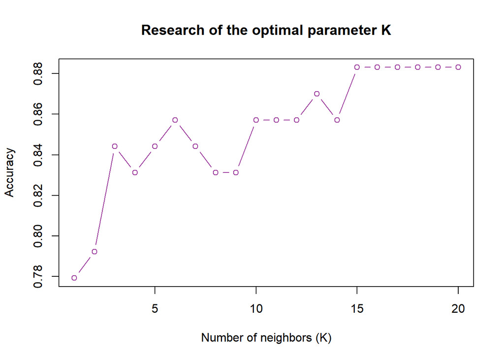

```r
set.seed(2711)

#Grid of parameters k
k_values <- seq(1, 20, by = 1)
accuracy_k <- c()

for (k in k_values) {
  pred_temp <- knn(train = X_train_KNN,
                   test  = X_test_KNN,
                   cl    = y_train_KNN,
                   k     = k)
  #Computation of accuracy
  acc <- sum(pred_temp == y_test_KNN) / length(y_test_KNN)
  accuracy_k <- c(accuracy_k, acc)
}

plot(k_values, accuracy_k, type="b", col="#983399",
     xlab="Number of neighbors (K)", ylab="Accuracy",
     main="Research of the optimal parameter K")
```

We confirm with a test that the optimal K is 15.

```r
set.seed(2711)

best_k <- k_values[which.max(accuracy_k)]
cat("Optimal parameter K:", best_k, "\n")
```

```
## Optimal parameter K: 15
```

Now, that we have define K, we can train the model.

```r
set.seed(2711)

KNN_model <- knn(train = X_train_KNN,
                test  = X_test_KNN,
                cl    = y_train_KNN, #class = the target
                k     = best_k,
                prob = TRUE)
```

To evaluate our model, we first compute the confusion matrix and plot some general statistics.

```r
KNN_cms <- caret::confusionMatrix(data = as.factor(KNN_model),
                          reference = as.factor(y_test_KNN),
                          positive = "1") #1 is the Recurred class

print(KNN_cms)
```

```
## Confusion Matrix and Statistics
##
##           Reference
## Prediction  0  1
##          0 54  8
##          1  1 14
##
##                Accuracy : 0.8831
##                  95% CI : (0.7897, 0.9451)
##     No Information Rate : 0.7143
##     P-Value [Acc > NIR] : 0.0003429
##
##                   Kappa : 0.6834
##
##  Mcnemar's Test P-Value : 0.0455003
##
##             Sensitivity : 0.6364
##             Specificity : 0.9818
##          Pos Pred Value : 0.9333
##          Neg Pred Value : 0.8710
##              Prevalence : 0.2857
##          Detection Rate : 0.1818
##    Detection Prevalence : 0.1948
##       Balanced Accuracy : 0.8091
##
##        'Positive' Class : 1
##
```

Then we give a visual representation of the confusion matrix.

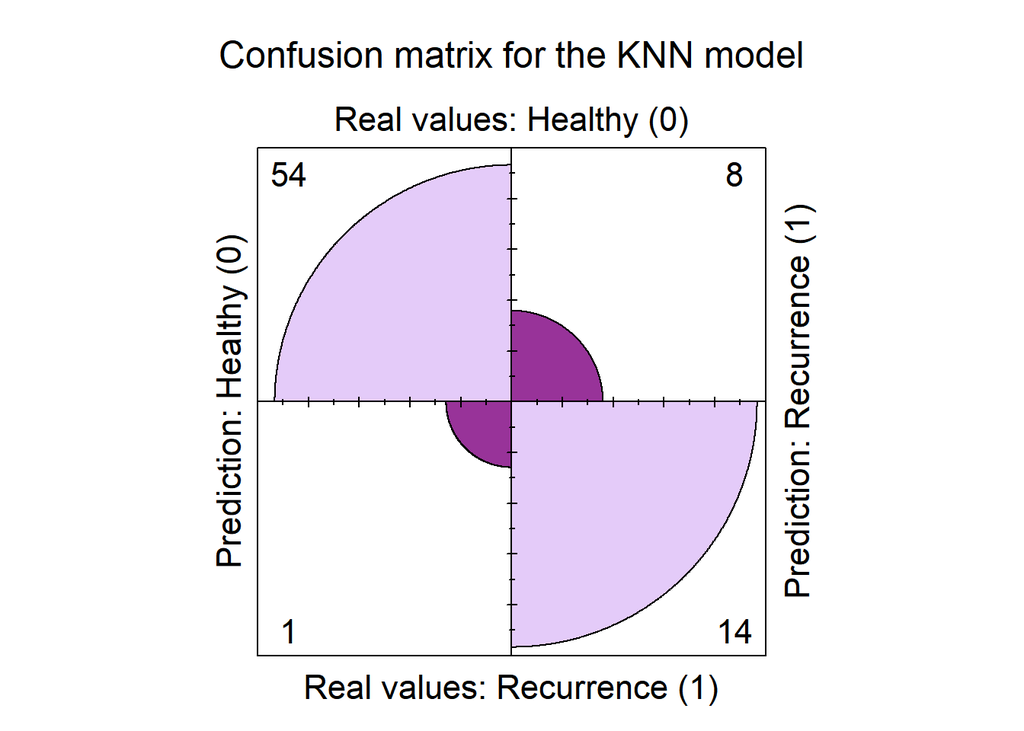

```r
confusion_matrix_KNN <- table(factor(KNN_model), factor(y_test_KNN))
par(mfrow=c(1, 1))
ctable_KNN <- as.table(confusion_matrix_KNN,
                   nrow = 2,
                   byrow = TRUE)
rownames(ctable_KNN) <- colnames(ctable_KNN) <- c("Healthy (0)", "Recurrence (1)")
dimnames(ctable_KNN) <- list(`Real values` = rownames(ctable_KNN), Prediction = colnames(ctable_KNN))

fourfoldplot(ctable_KNN,
             color = c("#983399", "#E4CBF9"),
             conf.level = 0,
             margin = 1,
             main = "Confusion matrix for the KNN model")
```

With this first model, 68 patients of the test set have been correctly classified, 8 patients are False-Negative (had recurrence but not classified so) and only one patient is False-Positive (no recurrence but classified as recurrent). The accuracy is equal to 0.88 and the recall is equal to 0.64. It indicates good performance in the majority of cases, however as False-Negative could have very dangerous consequences, we will try other models to reduce this number.

Finally, we plot the ROC Curve.

```r
#Preparation
raw_probs_KNN <- attr(KNN_model, "prob") #to have the proba
prob_positive_KNN <- ifelse(KNN_model == "Yes", raw_probs_KNN, 1 - raw_probs_KNN) #to take the proba when yes ie recurred
roc_pred_KNN <- prediction(prob_positive_KNN, y_test_KNN) #comparison of predicted and real values
roc_perf_KNN <- performance(roc_pred_KNN, measure = "tpr", x.measure = "fpr") #computation of the metrics

#AUC Computation
auc_perf_KNN <- performance(roc_pred_KNN, measure = "auc")
auc_value_KNN <- round(slot(auc_perf_KNN, "y.values")[[1]], 3)
auc_label_KNN <- paste("ROC curve (AUC =", auc_value_KNN, ")") #to directly add to the figure

#Creation of a nice dataframe
roc_values_KNN <- data.frame(Threshold = slot(roc_perf_KNN, "alpha.values")[[1]])
roc_values_KNN$FPR <- slot(roc_perf_KNN, "x.values")[[1]] #fpr on the x axis
roc_values_KNN$TPR <- slot(roc_perf_KNN, "y.values")[[1]] #tpr on the y axis

roc_values_KNN <- roc_values_KNN[is.finite(roc_values_KNN$Threshold), ] #to have only finite threshold

#Creation of the plot
plot_ly(data = roc_values_KNN, x = ~FPR) |>
  add_trace(y = ~TPR, mode = 'lines', name = auc_label_KNN, type = 'scatter',
            line = list(color = '#983399', width = 3)) |>
  add_segments(x = 0, xend = 1, y = 0, yend = 1,
               name = 'No skill model',
               line = list(dash = "dash", color = 'gray', width = 1),
               showlegend = TRUE) |>
  layout(title = 'ROC Curve (KNN)',
         xaxis = list(title = "False Positive Rate (1 - Specificity)"),
         yaxis = list(title = "True Positive Rate (Sensitivity)"),
         legend = list(title = list(text = '<b> Legend </b>')))
```

[interactive chart not shown]

## 4.2. Model 2: Logistic Regression with Lasso Regularisation (LR)

The Logistic regression method is a generalisation of linear modelsIn this we also add an L1 penalty, a Lasso regularisation. It will do variable selection by choosing an optimal coefficient for each feature and setting some of them to 0. For this reasons, we us the initial training set.

Once again, we start by seperating our sets: on one side the target and on the other side the covariates.

```r
set.seed(2711)

#Division of the target y and the set X
y_train_LR <- train_data$Recurred
X_train_LR <- train_data |> select(-Recurred)

y_test_LR <- test_data$Recurred
X_test_LR <- test_data |> select(-Recurred)
```

Then, we search the optimal regularisation parameter lambda.

```r
set.seed(2711)

grid_Lasso <- seq(0.01, 0.03, length = 100)

custom_LR <- caret::trainControl(method = "cv",
                       number = 10,
                       classProbs = TRUE,
                       summaryFunction = twoClassSummary) #important for the ROC curve

Lasso <- train(Recurred ~ ., data = train_data,
               method = 'glmnet',
               tuneGrid = expand.grid(alpha = 1, lambda = grid_Lasso),
               preProc = c("center", "scale"),
               metric = "ROC",
               trControl = custom_LR)

ggplotly(ggplot(Lasso$results, aes(x = lambda, y = ROC)) +
  geom_line(color = "#983399", size = 1) +
  geom_point(color = "#983399", size = 2)+
  labs(title = "Research of the optimal parameter of Lasso regularisation"))
```

[interactive chart not shown]

We confirm our choice with the function `bestTune`.

```r
Lasso$bestTune
```

|  | alpha | lambda |
| --- | --- | --- |
| 39 | 1 | 0.01767677 |

To evaluate our model, we first compute the confusion matrix and plot some general statistics.

```r
pred_classes_LR <- predict(Lasso, newdata = test_data) #predicted classes for the test set

pred_probs_LR <- predict(Lasso, newdata = test_data, type = "prob") #probabilty of such prediction

lasso_cms <- confusionMatrix(data = pred_classes_LR,
                               reference = y_test_LR,
                               positive = "Yes")

print(lasso_cms)
```

```
## Confusion Matrix and Statistics
##
##           Reference
## Prediction No Yes
##        No  55   4
##        Yes  0  18
##
##                Accuracy : 0.9481
##                  95% CI : (0.8723, 0.9857)
##     No Information Rate : 0.7143
##     P-Value [Acc > NIR] : 2.23e-07
##
##                   Kappa : 0.8654
##
##  Mcnemar's Test P-Value : 0.1336
##
##             Sensitivity : 0.8182
##             Specificity : 1.0000
##          Pos Pred Value : 1.0000
##          Neg Pred Value : 0.9322
##              Prevalence : 0.2857
##          Detection Rate : 0.2338
##    Detection Prevalence : 0.2338
##       Balanced Accuracy : 0.9091
##
##        'Positive' Class : Yes
##
```

Then we give a visual representation of the confusion matrix.

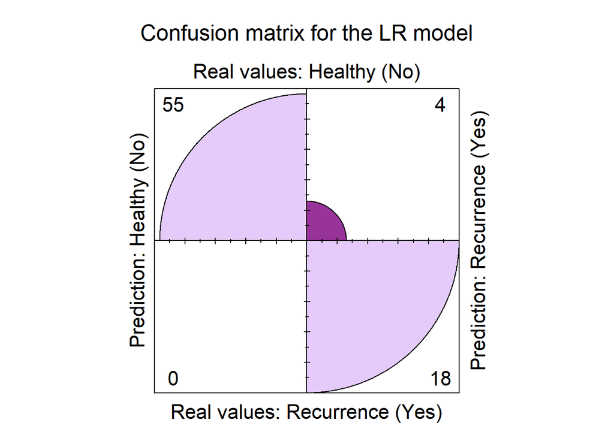

```r
confusion_matrix_LR <- table(factor(pred_classes_LR), factor(y_test_LR))
par(mfrow=c(1, 1))
ctable_LR <- as.table(confusion_matrix_LR,
                   nrow = 2,
                   byrow = TRUE)
rownames(ctable_LR) <- colnames(ctable_LR) <- c("Healthy (No)", "Recurrence (Yes)")
dimnames(ctable_LR) <- list(`Real values` = rownames(ctable_LR), Prediction = colnames(ctable_LR))

fourfoldplot(ctable_LR,
             color = c("#983399", "#E4CBF9"),
             conf.level = 0,
             margin = 1,
             main = "Confusion matrix for the LR model")
```

Finally, we plot the ROC Curve. It shows very good performances according to the North-West-Rule.

```r
#Preparation
lasso_probs_LR <- predict(Lasso, newdata = test_data, type = "prob")
prob_positive_LR <- lasso_probs_LR$Yes
roc_pred_LR <- prediction(prob_positive_LR, y_test_LR)
roc_perf_LR <- performance(roc_pred_LR, measure = "tpr", x.measure = "fpr")

#AUC Computation
auc_perf_LR <- performance(roc_pred_LR, measure = "auc")
auc_value_LR <- round(slot(auc_perf_LR, "y.values")[[1]], 3)
auc_label_LR <- paste("ROC curve (AUC =", auc_value_LR, ")")

#Creation of the dataframe
roc_values_LR <- data.frame(Threshold = slot(roc_perf_LR, "alpha.values")[[1]])
roc_values_LR$FPR <- slot(roc_perf_LR, "x.values")[[1]]
roc_values_LR$TPR <- slot(roc_perf_LR, "y.values")[[1]]
roc_values_LR <- roc_values_LR[is.finite(roc_values_LR$Threshold), ]

#Creation of the plot
plot_ly(data = roc_values_LR, x = ~FPR) |>
  add_trace(y = ~TPR, mode = 'lines', name = auc_label_LR, type = 'scatter',
            line = list(color = '#983399', width = 3)) |>
  add_segments(x = 0, xend = 1, y = 0, yend = 1,
               name = 'No skill model',
               line = list(dash = "dash", color = 'gray', width = 1),
               showlegend = TRUE) |>
  layout(title = 'ROC Curve (LR)',
         xaxis = list(title = "False Positive Rate (1 - Specificity)"),
         yaxis = list(title = "True Positive Rate (Sensitivity)"),
         legend = list(title = list(text = '<b> Legend </b>')))
```

[interactive chart not shown]

As this is a glm model, it enables us to interpret the effect of each selected feature on the probability of cancer recurrence. The following code presents the coefficients that remained non null after the L1 regularisation. The other features not listed in this figure are assumed to have negligible impact on the classification.

```r
#Creation of a dataframe
coef_matrix <- as.matrix(coef(Lasso$finalModel, s = Lasso$bestTune$lambda))
coef_df <- data.frame(
  Variable = rownames(coef_matrix),
  Coefficient = coef_matrix[, 1]
)

#We only keep the ones that are not null
coef_df <- coef_df[coef_df$Coefficient != 0 & coef_df$Variable != "(Intercept)", ]

coef_df <- coef_df[order(-abs(coef_df$Coefficient)), ] #To order them
rownames(coef_df) <- NULL

coef_df |> rmarkdown::paged_table()
```

| Variable | Coefficient |
| --- | --- |
| ResponseExcellent | -1.33244375 |
| ResponseStructural Incomplete | 1.18263183 |
| RiskLow | -0.55136080 |
| ResponseIndeterminate | -0.46324889 |
| StageII | 0.27560477 |
| NN1b | 0.20491250 |
| Age | 0.10117990 |
| PathologyHurthel cell | -0.05975526 |
| `Thyroid Function`Euthyroid | 0.04787256 |

Here is an another visualisation of the coefficients.

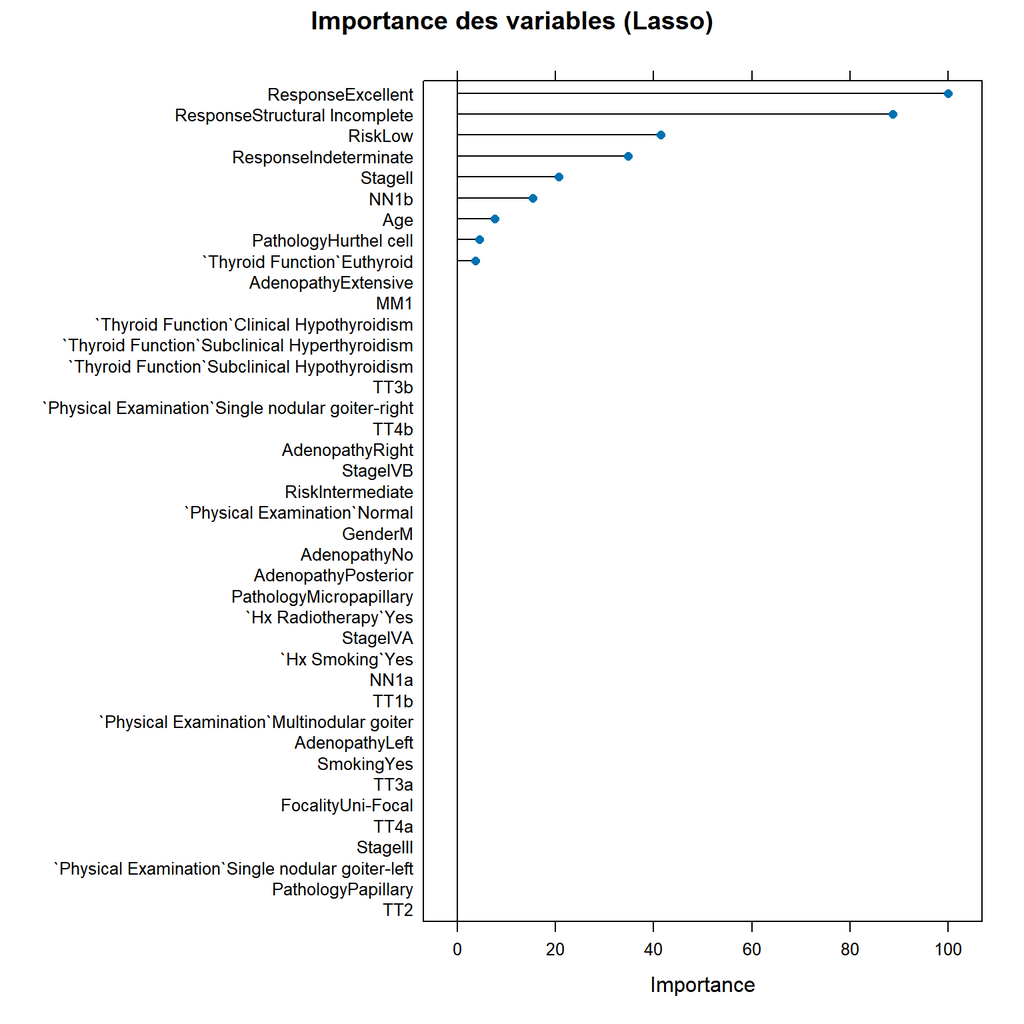

```r
# Calcule l'importance (de 0 à 100)
importance <- varImp(Lasso, scale = TRUE)

# Affiche le graphique
plot(importance, main = "Importance des variables (Lasso)")
```

## 4.3. Model 3: Random Forest (RF)

This last method, the Random Forest, is a bagging method which train several decision trees on independent sub-datasets. The final classification is the class which has the majority among the decision trees. This method requires neither variable selection nor one-hot encoding.

We start by seperating our sets: on one side the target and on the other side the covariates.

```r
set.seed(2711)

#Division of he target y and the set x
y_train_RF <- train_data$Recurred
X_train_RF <- train_data |> select(-Recurred)

y_test_RF <- test_data$Recurred
X_test_RF <- test_data |> select(-Recurred)
```

```r
set.seed(2711)

grid_RF <- expand.grid(mtry = c(2, 3, 4, 5, 6))

custom_RF <- caret::trainControl(method = "cv",
                       number = 10,
                       classProbs = TRUE,
                       summaryFunction = twoClassSummary) #same as LR

RF_model <- train(Recurred ~ .,
                  data = train_data,
                  method = "rf", #call the randomForest package
                  metric = "ROC",
                  tuneGrid = grid_RF,
                  trControl = custom_RF,
                  ntree = 500) #standard choice

ggplotly(ggplot(RF_model)+
  geom_line(color = "#983399", size = 1) +
  geom_point(color = "#983399", size = 2)) |>
  layout(title = "Research of the optimal parameter of the RF method",
         xaxis = list(title = "Number of features tested at each node"),
         yaxis = list(title = "ROC"),
         legend = list(title = list(text = '<b> Legend </b>')))
```

[interactive chart not shown]

```r
RF_model$bestTune
```

|  | mtry |
| --- | --- |
| 4 | 5 |

We observe an optimal parameter of 5. It is confirmed by the `bestTune` function. By default the `caret` package automatically select this parameter for the model and the rest of this study.

To evaluate our model, we first compute the confusion matrix and plot some general statistics.

```r
pred_classes_RF <- predict(RF_model, newdata = test_data) #predicted classes for the test set

RF_cms <- confusionMatrix(data = pred_classes_RF,
                               reference = y_test_RF,
                               positive = "Yes")

print(RF_cms)
```

```
## Confusion Matrix and Statistics
##
##           Reference
## Prediction No Yes
##        No  54   2
##        Yes  1  20
##
##                Accuracy : 0.961
##                  95% CI : (0.8903, 0.9919)
##     No Information Rate : 0.7143
##     P-Value [Acc > NIR] : 2.901e-08
##
##                   Kappa : 0.9032
##
##  Mcnemar's Test P-Value : 1
##
##             Sensitivity : 0.9091
##             Specificity : 0.9818
##          Pos Pred Value : 0.9524
##          Neg Pred Value : 0.9643
##              Prevalence : 0.2857
##          Detection Rate : 0.2597
##    Detection Prevalence : 0.2727
##       Balanced Accuracy : 0.9455
##
##        'Positive' Class : Yes
##
```

Then we give a visual representation of the confusion matrix.

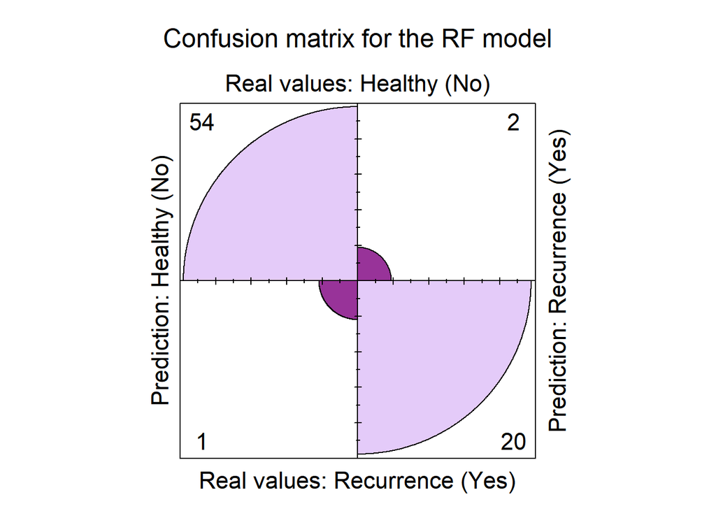

```r
confusion_matrix_RF <- table(factor(pred_classes_RF), factor(y_test_RF))
par(mfrow=c(1, 1))
ctable_RF <- as.table(confusion_matrix_RF,
                   nrow = 2,
                   byrow = TRUE)
rownames(ctable_RF) <- colnames(ctable_RF) <- c("Healthy (No)", "Recurrence (Yes)")
dimnames(ctable_RF) <- list(`Real values` = rownames(ctable_RF), Prediction = colnames(ctable_RF))

fourfoldplot(ctable_RF,
             color = c("#983399", "#E4CBF9"),
             conf.level = 0,
             margin = 1,
             main = "Confusion matrix for the RF model")
```

This last model shows better performances than the two others in the confusion matrix. Only three patients were misclassified: 1 False-Positive and 2 False-Negative. The accuracy is 0.96 and the recall 0.91. The ROC curve also shows great performances according to the North-West-Rule and an AUC of 0.99.

```r
#Preparation
lasso_probs_RF <- predict(RF_model, newdata = test_data, type = "prob")
prob_positive_RF <- lasso_probs_RF$Yes
roc_pred_RF <- prediction(prob_positive_RF, y_test_RF)
roc_perf_RF <- performance(roc_pred_RF, measure = "tpr", x.measure = "fpr")

#AUC Computation
auc_perf_RF <- performance(roc_pred_RF, measure = "auc")
auc_value_RF <- round(slot(auc_perf_RF, "y.values")[[1]], 3)
auc_label_RF <- paste("ROC curve (AUC =", auc_value_RF, ")")

#Creation of the dataframe
roc_values_RF <- data.frame(Threshold = slot(roc_perf_RF, "alpha.values")[[1]])
roc_values_RF$FPR <- slot(roc_perf_RF, "x.values")[[1]]
roc_values_RF$TPR <- slot(roc_perf_RF, "y.values")[[1]]
roc_values_RF <- roc_values_RF[is.finite(roc_values_RF$Threshold), ]

#Creation of the plot
plot_ly(data = roc_values_RF, x = ~FPR) |>
  add_trace(y = ~TPR, mode = 'lines', name = auc_label_RF, type = 'scatter',
            line = list(color = '#983399', width = 3)) |>
  add_segments(x = 0, xend = 1, y = 0, yend = 1,
               name = 'No skill model',
               line = list(dash = "dash", color = 'gray', width = 1),
               showlegend = TRUE) |>
  layout(title = 'ROC Curve (RF)',
         xaxis = list(title = "False Positive Rate (1 - Specificity)"),
         yaxis = list(title = "True Positive Rate (Sensitivity)"),
         legend = list(title = list(text = '<b> Legend </b>')))
```

[interactive chart not shown]

# 5. Performance comparison

The performance metrics of the three implemented models have been summarised in the following table. The Accuracy and the Recall are maximal for the RF model, and the AUC is optimal for the LR with Lasso regularisation.

```r
results_df <- data.frame(
  Model = c("KNN_model", "Lasso", "RF_model"),
  Accuracy = c(KNN_cms$overall["Accuracy"],
               lasso_cms$overall["Accuracy"],
               RF_cms$overall["Accuracy"]),
  Recall = c(KNN_cms$byClass["Sensitivity"],
             lasso_cms$byClass["Sensitivity"],
             RF_cms$byClass["Sensitivity"]),
  AUC = c(auc_value_KNN, auc_value_LR, auc_value_RF)
)
results_df[, 2:4] <- round(results_df[, 2:4], 3)

results_df |> rmarkdown::paged_table()
```

| Model | Accuracy | Recall | AUC |
| --- | --- | --- | --- |
| KNN_model | 0.883 | 0.636 | 0.762 |
| Lasso | 0.948 | 0.818 | 0.994 |
| RF_model | 0.961 | 0.909 | 0.987 |

# 6. Conclusion

Throughout this project, we developed three supervised learning models to predict the recurrence of thyroid cancer based on clinical and pathological features. We focused on three key performance metrics: Accuracy, Recall and AUC.

The Random Forest showed best performances for two of the three metrics. It still has a very good performance for the AUC with a value of 0.987. The Logistic Regression with Lasso Regularisation also performed very well on the three metrics with an optimal AUC. The K-Nearest Neighbors had the weakest results, especially for a Recall of 0.636 which was presented as a very important metric in this clinical setting. All values are presented in the previous table.

The Random Forest and the Logistic Regression both show very strong performances. Even if the Random Forest slightly outperforms the Logistic Regression, the choice will be made to select the Logistic Regression as it enables medical expert to understand the role of each factor in the final decision of the model. Indeed as the Random Forest is a black box, it is more complicated to understand how the model performs. Whereas the Logistic Regression is efficient, transparent and understandable which are qualities that are appreciated in a clinical environment.

One limitation of this dataset was that some modalities of some categorical feature did not have any values which limits the role of such modalities in the classification. It will be especially limiting if a new patient classify so as the model will not be able to use this information.

Finally, in order to help the medical team in there detection, a web-based application was developed in R shiny. This interface acts as a decision support tool, estimating the probability of recurrence based on our Lasso Logistic Regression model. It provides clinicians with an immediate risk assessment using the patient’s specific parameters. The tool is available at the following link:

https://axellemeric.shinyapps.io/axelle_meric/

The complete code of this project and the R shiny application can be found on the following GitHub repository:

https://github.com/AxelleMeric/Thyroid-Cancer-Recurrence_Data-Visualisation

# References

[1] Google. Use of Generative AI to help with bug in the code and to implement an R shiny app, however always under supervision and has been entirely mastered.

[2] Kaggle. *Kaggle. Kaggle page dedicated to the dataset, however no project done in R.* URL: [https://www.kaggle.com/datasets/joebeachcapital/differentiated-thyroid-cancer-recurrence…](https://www.kaggle.com/datasets/joebeachcapital/differentiated-thyroid-cancer-recurrence/code?datasetId=4324904&language=Python&outputs=Visualization)

[3] Katia Meziani. *Regression and Classification methods Course Notes.* Course material from Université Dauphine-PSL / M2 ISF. Lecture notes used in the Regression and Classification methods course. Academic Year 2025-2026.

[4] RDocumentation. URL: https://www.rdocumentation.org/.

[5] Aidin Tarokhian, Shiva Borzooei. *Differentiated Thyroid Cancer Recurrence.* 2023. DOI: 10.24432/C5632J. URL: https://archive.ics.uci.edu/dataset/915.

[6] *Thyroid Cancer Recurrence Project of M1 Statistical learning class, Python code.ipynb at main · AxelleMeric/Thyroid-Cancer-Recurrence_Data-Visualisation.* en. URL: https://github.com/AxelleMeric/Thyroid-Cancer-Recurrence_Data-Visualisation/blob/main/Python%20code.ipynb.

[7] *Thyroid Cancer Recurrence Project of M1 Statistical learning class, Report of Python code at main · AxelleMeric/Thyroid-Cancer-Recurrence_Data-Visualisation.* en. URL: https://github.com/AxelleMeric/Thyroid-Cancer-Recurrence_Data-Visualisation/blob/main/Project%20Report%20in%20Python.pdf.